# Deep Learning CA2 Part A

## GAN vs VAE Comparison and Final Selection

This notebook is the final integration and evaluation stage of the CIFAR-10 generative-modelling project.

The GAN and VAE development programmes are complete before this notebook begins. Their selected architectures, hyperparameters and checkpoints are frozen. This notebook verifies the frozen artifacts, defines one common final-evaluation protocol, performs the protected held-out comparison, selects the overall model, and generates the official 1,000-image submission set.

No model training or tuning is performed here.

## 1. Notebook Overview and Frozen-Model Boundary

### 1.1 Purpose

This notebook has five main responsibilities:

1. independently reconstruct and verify the frozen final GAN and VAE;
2. freeze one fair final-evaluation protocol before protected-test evaluation begins;
3. compare both models using held-out, blind-human and memorisation evidence;
4. select and freeze the overall GAN-versus-VAE winner;
5. generate exactly 1,000 final CIFAR-10 images, with 100 requested samples per class, and verify the saved deliverable at file level.

The modelling phase is closed. No architecture, hyperparameter, augmentation, conditioning, checkpoint or training-seed decision will be reopened in this notebook.

### 1.2 Relationship to Notebooks 1–3

| Notebook | Main responsibility | Status entering Notebook 4 |
| --- | --- | --- |
| Notebook 1 | CIFAR-10 EDA, preprocessing, shared representation, grayscale and augmentation context | Complete |
| Notebook 2 | GAN development, controlled experiments, within-family selection and final GAN freeze | Complete and frozen |
| Notebook 3 | VAE development, controlled experiments, within-family selection and final VAE freeze | Complete and frozen |
| Notebook 4 | Frozen-model verification, final shared evaluation, cross-model selection and official generation | Current notebook |

Notebook 4 reuses the decisions and valid development evidence from the earlier notebooks rather than repeating their experiments.

### 1.3 Final Data-Use and No-Tuning Policy

The official CIFAR-10 test set was not used to train, tune, select or revise either final generative model.

The final GAN and VAE enter this notebook as frozen artifacts. Before the protected test set is accessed, this notebook must:

- independently reload both frozen generation networks;
- verify their expected input and output interfaces;
- verify conversion into the shared RGB `uint8 [0,255]` representation;
- write and freeze the complete final-evaluation protocol.

After protected-test evaluation begins:

- no retraining is allowed;
- no checkpoint or model reselection is allowed;
- no hyperparameter or architecture change is allowed;
- no outcome-driven evaluation-protocol change is allowed.

A genuine implementation error may be corrected transparently, but any affected comparison must then be rerun symmetrically.

### 1.4 Notebook Roadmap

```
verify frozen GAN and VAE
        ↓
freeze final evaluation protocol
        ↓
one-time protected-test evaluation
        ↓
fresh blind GAN-vs-VAE comparison
        ↓
formal memorisation audit
        ↓
consolidate development evidence
        ↓
select and freeze overall winner
        ↓
generate exactly 1,000 final images
        ↓
audit 100 requested samples per CIFAR-10 class
```

| Stage | Permitted in Notebook 4? |
| --- | --- |
| Load frozen weights | Yes |
| Generate from frozen models | Yes |
| Evaluate frozen models | Yes |
| Retrain either model | No |
| Change architecture or hyperparameters | No |
| Select another checkpoint | No |
| Add new modelling experiments | No |
| Use protected-test results for tuning | No |

## 2. Environment, Data and Frozen Artifact Verification

This section verifies that the exact frozen GAN generator and VAE decoder can be reconstructed and used correctly before the protected final-evaluation protocol is activated.

No CIFAR-10 test images are loaded or evaluated in this section.

### 2.1 Environment and Reproducibility

The final comparison uses a lightweight notebook-local setup. Environment versions are recorded for reproducibility, while the final evaluation seeds and sample counts remain pending until the Section 3 protocol is approved and frozen.

The seed used in this section is only for artifact-verification samples. It is not a final evaluation seed.

```python
import os
import sys
from pathlib import Path


ROOT_DIR = Path(
    "[local project directory]"
)

# Reuse the persistent Keras cache already created in Notebook 2.
KERAS_HOME_DIR = ROOT_DIR / ".keras"
os.environ["KERAS_HOME"] = str(KERAS_HOME_DIR)

# Import libraries only after KERAS_HOME is fixed.
import numpy as np
import pandas as pd
import matplotlib
import scipy
import sklearn
import tensorflow as tf

from tensorflow import keras
from tensorflow.keras import layers, initializers


# Reproducibility

ARTIFACT_VERIFICATION_SEED = 1701
tf.keras.utils.set_random_seed(ARTIFACT_VERIFICATION_SEED)


# Shared project constants

CLASS_NAMES = [
    "Airplane",
    "Automobile",
    "Bird",
    "Cat",
    "Deer",
    "Dog",
    "Frog",
    "Horse",
    "Ship",
    "Truck",
]

NUM_CLASSES = 10

GAN_LATENT_DIM = 100
GAN_LABEL_EMBEDDING_DIM = 50
EXPECTED_GAN_GENERATOR_PARAMS = 1_290_487

VAE_LATENT_DIM = 64
EXPECTED_VAE_DECODER_PARAMS = 394_307


# Frozen artifact locations

ROOT_DIR = Path("[local project directory]")

GAN_GENERATOR_WEIGHTS_PATH = (
    ROOT_DIR / "models" / "best_gan_generator.weights.h5"
)

VAE_DECODER_MODEL_PATH = (
    ROOT_DIR / "models" / "VAE_FINAL_V04_decoder.keras"
)


# Environment record

environment_table = pd.DataFrame(
    {
        "Component": [
            "Python",
            "TensorFlow",
            "Keras",
            "NumPy",
            "Pandas",
            "SciPy",
            "scikit-learn",
            "Matplotlib",
        ],
        "Version": [
            sys.version.split()[0],
            tf.__version__,
            keras.__version__,
            np.__version__,
            pd.__version__,
            scipy.__version__,
            sklearn.__version__,
            matplotlib.__version__,
        ],
    }
)

display(environment_table)

print("\nArtifact-verification seed:", ARTIFACT_VERIFICATION_SEED)
print("GAN generator weights:", GAN_GENERATOR_WEIGHTS_PATH)
print("VAE decoder model:", VAE_DECODER_MODEL_PATH)
```

|  | Component | Version |
| --- | --- | --- |
| 0 | Python | 3.12.13 |
| 1 | TensorFlow | 2.20.0 |
| 2 | Keras | 3.13.2 |
| 3 | NumPy | 2.0.2 |
| 4 | Pandas | 2.2.2 |
| 5 | SciPy | 1.16.3 |
| 6 | scikit-learn | 1.6.1 |
| 7 | Matplotlib | 3.10.0 |

```
Artifact-verification seed: 1701
GAN generator weights: [local project directory]/best_gan_generator.weights.h5
VAE decoder model: [local project directory]/VAE_FINAL_V04_decoder.keras
```

```python
import matplotlib.pyplot as plt
```

### 2.2 CIFAR-10 Contract and Protected-Test Firewall

Notebook 1 established the common CIFAR-10 data contract:

- 50,000 official training images;
- 10,000 official test images;
- RGB images with shape `32 × 32 × 3`;
- original storage as `uint8 [0,255]`;
- fixed class labels `0` to `9`;
- fixed class order from Airplane to Truck.

For the stricter final-evaluation firewall used in this notebook, the actual CIFAR-10 loader is deliberately **not called yet**. The Keras loader returns both training and test data together, so loading it here would access the protected test set before the complete Section 3 protocol is frozen.

The official dataset will therefore be loaded and validated only after Section 3 has been approved and the protected-test gate has opened.

This section only verifies the inherited representation contract and the inverse conversions required for frozen-model outputs.

```python
# Protected test data has deliberately not been loaded in Notebook 4.
PROTECTED_TEST_ACCESSED_IN_NOTEBOOK4 = False

assert len(CLASS_NAMES) == NUM_CLASSES
assert CLASS_NAMES == [
    "Airplane",
    "Automobile",
    "Bird",
    "Cat",
    "Deer",
    "Dog",
    "Frog",
    "Horse",
    "Ship",
    "Truck",
]


def restore_from_gan(images):
    """Convert GAN outputs from approximately [-1, 1] to uint8 [0, 255]."""
    restored = (np.asarray(images) + 1.0) * 127.5
    return np.clip(
        np.rint(restored),
        0,
        255,
    ).astype("uint8")


def restore_from_vae(images):
    """Convert VAE outputs from [0, 1] to uint8 [0, 255]."""
    restored = np.asarray(images) * 255.0
    return np.clip(
        np.rint(restored),
        0,
        255,
    ).astype("uint8")


# Boundary checks for the inherited conversions.
assert np.array_equal(
    restore_from_gan(
        np.array([-1.0, 1.0], dtype=np.float32)
    ),
    np.array([0, 255], dtype=np.uint8),
)

assert np.array_equal(
    restore_from_vae(
        np.array([0.0, 1.0], dtype=np.float32)
    ),
    np.array([0, 255], dtype=np.uint8),
)

print("CIFAR-10 class contract: PASS")
print("GAN inverse conversion: PASS")
print("VAE inverse conversion: PASS")
print("Protected test access in Notebook 4: NOT PERFORMED")
```

```
CIFAR-10 class contract: PASS
GAN inverse conversion: PASS
VAE inverse conversion: PASS
Protected test access in Notebook 4: NOT PERFORMED
```

### 2.3 Final GAN Reload Verification

Notebook 2 selected and froze `G10_conditional_fliptranslation_seed42` at epoch 100.

The final generator uses:

- latent dimension `100`;
- integer requested-class labels with shape `(N,1)`;
- a learned label embedding of dimension `50`;
- RGB output with shape `32 × 32 × 3`;
- `tanh` output activation, producing values approximately in `[-1,1]`;
- `1,290,487` generator parameters.

A fresh generator is reconstructed below from the final Notebook 2 architecture and loaded from the frozen `.h5` weights. Only a small balanced inference batch is generated. This is an artifact-verification step, not final evaluation.

```python
def build_final_gan_generator(
    latent_dim=GAN_LATENT_DIM,
    num_classes=NUM_CLASSES,
    label_embedding_dim=GAN_LABEL_EMBEDDING_DIM,
):
    weight_init = initializers.RandomNormal(
        mean=0.0,
        stddev=0.02,
    )

    noise_input = layers.Input(
        shape=(latent_dim,),
        name="conditional_noise_input",
    )

    label_input = layers.Input(
        shape=(1,),
        dtype="int32",
        name="conditional_generator_label",
    )

    label_embedding = layers.Embedding(
        input_dim=num_classes,
        output_dim=label_embedding_dim,
        embeddings_initializer=weight_init,
        name="generator_label_embedding",
    )(label_input)

    label_embedding = layers.Flatten(
        name="generator_label_flatten"
    )(label_embedding)

    x = layers.Concatenate(
        name="generator_conditioning_concatenation"
    )(
        [
            noise_input,
            label_embedding,
        ]
    )

    x = layers.Dense(
        4 * 4 * 256,
        use_bias=False,
        kernel_initializer=weight_init,
    )(x)

    x = layers.BatchNormalization()(x)
    x = layers.LeakyReLU(negative_slope=0.2)(x)
    x = layers.Reshape((4, 4, 256))(x)

    x = layers.Conv2DTranspose(
        128,
        kernel_size=4,
        strides=2,
        padding="same",
        use_bias=False,
        kernel_initializer=weight_init,
    )(x)

    x = layers.BatchNormalization()(x)
    x = layers.LeakyReLU(negative_slope=0.2)(x)

    x = layers.Conv2DTranspose(
        64,
        kernel_size=4,
        strides=2,
        padding="same",
        use_bias=False,
        kernel_initializer=weight_init,
    )(x)

    x = layers.BatchNormalization()(x)
    x = layers.LeakyReLU(negative_slope=0.2)(x)

    generated_image = layers.Conv2DTranspose(
        3,
        kernel_size=4,
        strides=2,
        padding="same",
        activation="tanh",
        kernel_initializer=weight_init,
        name="conditional_generated_image",
    )(x)

    return keras.Model(
        inputs=[
            noise_input,
            label_input,
        ],
        outputs=generated_image,
        name="Conditional_DCGAN_Generator",
    )


assert GAN_GENERATOR_WEIGHTS_PATH.is_file(), (
    "Frozen GAN generator weights were not found at:\n"
    f"{GAN_GENERATOR_WEIGHTS_PATH}"
)

final_gan_generator = build_final_gan_generator()

assert (
    final_gan_generator.count_params()
    == EXPECTED_GAN_GENERATOR_PARAMS
)

final_gan_generator.load_weights(
    str(GAN_GENERATOR_WEIGHTS_PATH)
)

# One requested sample per CIFAR-10 class.
gan_verification_labels = tf.reshape(
    tf.range(NUM_CLASSES, dtype=tf.int32),
    (-1, 1),
)

gan_verification_noise = tf.random.stateless_normal(
    shape=(NUM_CLASSES, GAN_LATENT_DIM),
    seed=(ARTIFACT_VERIFICATION_SEED, 42),
)

gan_native_images = final_gan_generator(
    [
        gan_verification_noise,
        gan_verification_labels,
    ],
    training=False,
).numpy()

assert gan_native_images.shape == (
    NUM_CLASSES,
    32,
    32,
    3,
)

assert np.isfinite(gan_native_images).all()
assert gan_native_images.min() >= -1.0001
assert gan_native_images.max() <= 1.0001

gan_uint8_images = restore_from_gan(
    gan_native_images
)

assert gan_uint8_images.shape == (
    NUM_CLASSES,
    32,
    32,
    3,
)
assert gan_uint8_images.dtype == np.uint8


GAN_RELOAD_VERIFIED = True

print("Final GAN reload verification: PASS")
print(
    "Generator parameters:",
    f"{final_gan_generator.count_params():,}",
)
print("Conditional label shape:", gan_verification_labels.shape)
print("Native output shape:", gan_native_images.shape)
print(
    "Native output range:",
    f"[{gan_native_images.min():.4f}, "
    f"{gan_native_images.max():.4f}]",
)
print("Shared output dtype:", gan_uint8_images.dtype)
print(
    "Shared output range:",
    f"[{gan_uint8_images.min()}, "
    f"{gan_uint8_images.max()}]",
)
```

```
Final GAN reload verification: PASS
Generator parameters: 1,290,487
Conditional label shape: (10, 1)
Native output shape: (10, 32, 32, 3)
Native output range: [-0.9990, 1.0000]
Shared output dtype: uint8
Shared output range: [0, 255]
```

### 2.4 Final VAE Reload Verification

Notebook 3 exported a standalone frozen decoder model as `VAE_FINAL_V04_decoder.keras`.

The artifact was created under the legacy Keras environment used for Notebook 3 and is physically stored as an HDF5 whole-model file despite its `.keras` filename. Modern Keras reserves `.keras` for its newer native ZIP-based format. Therefore, Notebook 4 preserves the original artifact unchanged and creates a temporary `.h5` compatibility copy in the runtime before loading it for inference.

No weights are modified and no VAE training occurs in this notebook.

```python
import json
import shutil
import h5py

assert VAE_DECODER_MODEL_PATH.is_file(), (
    "Frozen V04 standalone decoder was not found at:\n"
    f"{VAE_DECODER_MODEL_PATH}"
)

assert h5py.is_hdf5(str(VAE_DECODER_MODEL_PATH)), (
    "Expected the supplied V04 decoder to be a legacy HDF5 model."
)

# -------------------------------------------------------
# Legacy Keras 2 -> Keras 3 compatibility copy
# -------------------------------------------------------
#
# Notebook 3 saved the decoder under Keras 2.x.
# Its serialized Conv2DTranspose configuration contains
# the legacy field `groups=1`, even though the original
# V04 architecture did not specify grouped transposed
# convolution.
#
# Current Keras Conv2DTranspose does not accept `groups`.
# Patch only that stale configuration field in a temporary
# runtime copy. The original frozen artifact remains unchanged.
# -------------------------------------------------------

VAE_DECODER_COMPAT_PATH = Path(
    "/tmp/VAE_FINAL_V04_decoder_compat.h5"
)

shutil.copy2(
    VAE_DECODER_MODEL_PATH,
    VAE_DECODER_COMPAT_PATH,
)


def remove_legacy_convtranspose_groups(config):
    """Remove only legacy groups=1 from Conv2DTranspose configs."""
    patched_count = 0

    if isinstance(config, dict):
        if (
            config.get("class_name") == "Conv2DTranspose"
            and isinstance(config.get("config"), dict)
            and "groups" in config["config"]
        ):
            groups_value = config["config"]["groups"]

            assert groups_value == 1, (
                "Unexpected grouped Conv2DTranspose found. "
                f"groups={groups_value}"
            )

            del config["config"]["groups"]
            patched_count += 1

        for value in config.values():
            patched_count += remove_legacy_convtranspose_groups(
                value
            )

    elif isinstance(config, list):
        for value in config:
            patched_count += remove_legacy_convtranspose_groups(
                value
            )

    return patched_count


with h5py.File(
    VAE_DECODER_COMPAT_PATH,
    "r+",
) as h5_file:

    assert "model_config" in h5_file.attrs, (
        "Legacy model does not contain model_config."
    )

    raw_model_config = h5_file.attrs[
        "model_config"
    ]

    if isinstance(raw_model_config, bytes):
        raw_model_config = raw_model_config.decode(
            "utf-8"
        )

    model_config = json.loads(
        raw_model_config
    )

    patched_layer_count = (
        remove_legacy_convtranspose_groups(
            model_config
        )
    )

    assert patched_layer_count == 3, (
        "Expected exactly three V04 Conv2DTranspose "
        "layers to require the legacy compatibility patch, "
        f"but found {patched_layer_count}."
    )

    h5_file.attrs["model_config"] = json.dumps(
        model_config
    )


print(
    "Legacy Conv2DTranspose configs patched:",
    patched_layer_count,
)

# -------------------------------------------------------
# Load the frozen decoder
# -------------------------------------------------------

final_vae_decoder = keras.models.load_model(
    str(VAE_DECODER_COMPAT_PATH),
    compile=False,
)

# -------------------------------------------------------
# Frozen decoder verification
# -------------------------------------------------------

assert (
    final_vae_decoder.count_params()
    == EXPECTED_VAE_DECODER_PARAMS
)

assert len(final_vae_decoder.inputs) == 2

assert tuple(
    final_vae_decoder.inputs[0].shape[1:]
) == (VAE_LATENT_DIM,)

assert tuple(
    final_vae_decoder.inputs[1].shape[1:]
) == (NUM_CLASSES,)

# One deterministic verification sample per class.
vae_verification_label_ids = tf.range(
    NUM_CLASSES,
    dtype=tf.int32,
)

vae_verification_labels = tf.one_hot(
    vae_verification_label_ids,
    depth=NUM_CLASSES,
    dtype=tf.float32,
)

vae_verification_latents = tf.random.stateless_normal(
    shape=(
        NUM_CLASSES,
        VAE_LATENT_DIM,
    ),
    seed=(
        ARTIFACT_VERIFICATION_SEED,
        64,
    ),
)

vae_native_images = final_vae_decoder(
    [
        vae_verification_latents,
        vae_verification_labels,
    ],
    training=False,
).numpy()

assert vae_native_images.shape == (
    NUM_CLASSES,
    32,
    32,
    3,
)

assert np.isfinite(
    vae_native_images
).all()

assert vae_native_images.min() >= 0.0
assert vae_native_images.max() <= 1.0

vae_uint8_images = restore_from_vae(
    vae_native_images
)

assert vae_uint8_images.shape == (
    NUM_CLASSES,
    32,
    32,
    3,
)

assert vae_uint8_images.dtype == np.uint8

VAE_RELOAD_VERIFIED = True

print("\nFinal VAE decoder reload verification: PASS")
print(
    "Original artifact:",
    VAE_DECODER_MODEL_PATH.name,
)
print(
    "Compatibility action:",
    "removed legacy groups=1 from "
    "3 Conv2DTranspose configs",
)
print(
    "Decoder parameters:",
    f"{final_vae_decoder.count_params():,}",
)
print(
    "Decoder input shapes:",
    [
        tuple(x.shape)
        for x in final_vae_decoder.inputs
    ],
)
print(
    "One-hot label shape:",
    vae_verification_labels.shape,
)
print(
    "Native output shape:",
    vae_native_images.shape,
)
print(
    "Native output range:",
    f"[{vae_native_images.min():.4f}, "
    f"{vae_native_images.max():.4f}]",
)
print(
    "Shared output dtype:",
    vae_uint8_images.dtype,
)
print(
    "Shared output range:",
    f"[{vae_uint8_images.min()}, "
    f"{vae_uint8_images.max()}]",
)
```

```
Legacy Conv2DTranspose configs patched: 3

Final VAE decoder reload verification: PASS
Original artifact: VAE_FINAL_V04_decoder.keras
Compatibility action: removed legacy groups=1 from 3 Conv2DTranspose configs
Decoder parameters: 394,307
Decoder input shapes: [(None, 64), (None, 10)]
One-hot label shape: (10, 10)
Native output shape: (10, 32, 32, 3)
Native output range: [0.0396, 0.9829]
Shared output dtype: uint8
Shared output range: [10, 251]
```

### 2.5 Shared RGB Evaluation Representation

Although the two frozen models use different native numerical ranges, their outputs are converted before any shared evaluation.

The common representation is:

```
shape  = (N, 32, 32, 3)
colour = RGB
dtype  = uint8
range  = [0,255]
```

The GAN uses the inherited inverse transformation from `[-1,1]`, while the VAE uses the inherited inverse transformation from `[0,1]`.

The real CIFAR-10 arrays will be checked against the same representation after the Section 3 protocol has been frozen and protected-test access becomes permitted.

```python
def verify_shared_image_representation(
    name,
    images,
):
    assert isinstance(images, np.ndarray)
    assert images.ndim == 4
    assert images.shape[1:] == (32, 32, 3)
    assert images.dtype == np.uint8
    assert images.min() >= 0
    assert images.max() <= 255

    return {
        "Source": name,
        "Shape": str(images.shape),
        "dtype": str(images.dtype),
        "Minimum": int(images.min()),
        "Maximum": int(images.max()),
        "Status": "PASS",
    }


representation_rows = [
    verify_shared_image_representation(
        "Frozen GAN",
        gan_uint8_images,
    ),
    verify_shared_image_representation(
        "Frozen VAE",
        vae_uint8_images,
    ),
]

representation_table = pd.DataFrame(
    representation_rows
)

display(representation_table)

SHARED_GENERATED_REPRESENTATION_VERIFIED = True

print(
    "Generated-image shared representation: PASS"
)
print(
    "Real CIFAR-10 representation: "
    "DEFERRED until Section 3 protocol freeze"
)
```

|  | Source | Shape | dtype | Minimum | Maximum | Status |
| --- | --- | --- | --- | --- | --- | --- |
| 0 | Frozen GAN | (10, 32, 32, 3) | uint8 | 0 | 255 | PASS |
| 1 | Frozen VAE | (10, 32, 32, 3) | uint8 | 10 | 251 | PASS |

```
Generated-image shared representation: PASS
Real CIFAR-10 representation: DEFERRED until Section 3 protocol freeze
```

### 2.6 Freeze-Gate Audit

The final model artifacts must pass independent reconstruction and common-representation checks before the final protocol can be frozen.

At the end of Section 2, the protected-test gate intentionally remains closed because Section 3 has not yet been approved. Passing this section verifies the models; it does not authorise protected-test evaluation.

```python
assert GAN_RELOAD_VERIFIED
assert VAE_RELOAD_VERIFIED
assert SHARED_GENERATED_REPRESENTATION_VERIFIED
assert PROTECTED_TEST_ACCESSED_IN_NOTEBOOK4 is False

freeze_gate_table = pd.DataFrame(
    [
        {
            "Requirement": "Architecture frozen",
            "GAN": "PASS",
            "VAE": "PASS",
            "Shared protocol": "N/A",
        },
        {
            "Requirement": "Checkpoint frozen",
            "GAN": "PASS",
            "VAE": "PASS",
            "Shared protocol": "N/A",
        },
        {
            "Requirement": "Final generation artifact reload",
            "GAN": "PASS",
            "VAE": "PASS",
            "Shared protocol": "N/A",
        },
        {
            "Requirement": "Native output contract",
            "GAN": "PASS",
            "VAE": "PASS",
            "Shared protocol": "N/A",
        },
        {
            "Requirement": "Shared RGB uint8 conversion",
            "GAN": "PASS",
            "VAE": "PASS",
            "Shared protocol": "PASS",
        },
        {
            "Requirement": "Protected test used for development",
            "GAN": "NO",
            "VAE": "NO",
            "Shared protocol": "NO",
        },
        {
            "Requirement": "Protected test accessed in Notebook 4",
            "GAN": "NO",
            "VAE": "NO",
            "Shared protocol": "NO",
        },
        {
            "Requirement": "Unresolved model-tuning decision",
            "GAN": "NONE",
            "VAE": "NONE",
            "Shared protocol": "NONE",
        },
        {
            "Requirement": "Final evaluation protocol frozen",
            "GAN": "N/A",
            "VAE": "N/A",
            "Shared protocol": "PENDING SECTION 3",
        },
    ]
)

display(freeze_gate_table)

MODELS_VERIFIED = True
FINAL_PROTOCOL_FROZEN = False

PROTECTED_TEST_GATE_OPEN = (
    MODELS_VERIFIED
    and FINAL_PROTOCOL_FROZEN
)

assert PROTECTED_TEST_GATE_OPEN is False

print("Section 2 frozen-model verification: COMPLETE")
print("Protected-test gate: CLOSED")
print("Reason: Section 3 final protocol is not yet frozen.")
```

|  | Requirement | GAN | VAE | Shared protocol |
| --- | --- | --- | --- | --- |
| 0 | Architecture frozen | PASS | PASS | N/A |
| 1 | Checkpoint frozen | PASS | PASS | N/A |
| 2 | Final generation artifact reload | PASS | PASS | N/A |
| 3 | Native output contract | PASS | PASS | N/A |
| 4 | Shared RGB uint8 conversion | PASS | PASS | PASS |
| 5 | Protected test used for development | NO | NO | NO |
| 6 | Protected test accessed in Notebook 4 | NO | NO | NO |
| 7 | Unresolved model-tuning decision | NONE | NONE | NONE |
| 8 | Final evaluation protocol frozen | N/A | N/A | PENDING SECTION 3 |

```
Section 2 frozen-model verification: COMPLETE
Protected-test gate: CLOSED
Reason: Section 3 final protocol is not yet frozen.
```

## 3. Final Shared Evaluation Protocol

Before any protected-test result is produced, the final comparison protocol is written and frozen.

This prevents the official CIFAR-10 test set from influencing model selection, sampling choices, evaluation settings, or interpretation thresholds.

Both frozen models will be evaluated as fairly as possible using the same:

- real-image reference where applicable;
- RGB `uint8 [0,255]` representation;
- generated sample counts;
- requested-class balance;
- feature extractor and preprocessing;
- human-scoring definitions;
- memorisation representation and nearest-neighbour procedure.

Model-specific evidence from earlier notebooks remains valid supporting evidence, but Notebook 4 will not rerun old analyses merely to force artificial symmetry between the GAN and VAE.

### 3.1 Protected-Test FID Protocol

Final FID uses the official CIFAR-10 test split only as an unseen real-image reference.

The protocol is:

- real reference: all `10,000` official CIFAR-10 test images;
- generated images per model per repeat: `5,000`;
- requested class balance: `500` images per class;
- repeats: `3`;
- generation seeds: `2001`, `2002`, `2003`;
- feature extractor: frozen ImageNet InceptionV3;
- feature layer: global average pooling;
- feature dimension: `2,048`;
- identical resizing and Inception preprocessing for real, GAN and VAE images.

The same repeat seeds and evaluation implementation will be used for both frozen models.

For each model, report the three FID values, mean, standard deviation and sample count.

The repeated FID standard deviation represents generated-sample variability for the already-frozen model. It is not training-run uncertainty.

No formal cross-model FID threshold is used. In particular, the `2.0` practical FID margin used during GAN development is not transferred to this final GAN-versus-VAE comparison because it was calibrated for a different source of variation.

FID is therefore one important final evidence dimension, not an automatic winner-selection rule.

### 3.2 Fresh Model-Identity-Masked Human Evaluation

Development manual scores were produced separately inside the GAN and VAE notebooks. Notebook 4 therefore performs one fresh common comparison.

Generate:

- `100` GAN images;
- `100` VAE images;
- `10` requested images per CIFAR-10 class per model.

The 200 images are combined and reproducibly shuffled before scoring.

#### Phase A: visual quality

During visual-quality scoring:

- model identity is hidden;
- requested class is hidden;
- images are identified only by anonymous IDs.

Each image receives exactly one rating:

- `Clear`
- `Marginal`
- `Nonsense`

#### Phase B: requested-class adherence

Requested labels are then revealed while model identity remains hidden.

Each image receives exactly one class-adherence rating:

- `Correct`
- `Ambiguous`
- `Incorrect`

Visual quality and requested-class adherence are treated as separate judgements.

All 200 images will be scored by Rudhresh using the same predefined criteria.

The shuffled anonymous image IDs and raw ratings will be preserved so that the scoring process remains reproducible and auditable. Because Notebook 4 uses a single scorer, no inter-rater agreement statistic is reported.

This single-rater design is treated as a limitation of the manual evaluation, while model-identity masking and fixed scoring definitions reduce avoidable scoring bias.

### 3.3 Formal Memorisation-Audit Protocol

The memorisation audit asks whether generated images are unusually close to particular CIFAR-10 training examples relative to genuine unseen CIFAR-10 images.

The shared reference bank is:

- all `50,000` CIFAR-10 training images.

The unseen-real baseline is:

- all `10,000` CIFAR-10 test images → nearest training image.

Generated audits use:

- `5,000` final GAN images → nearest training image;
- `5,000` final VAE images → nearest training image.

To avoid unnecessary extra generation, the memorisation audit will reuse each model's first frozen FID generation pool, corresponding to seed `2001`.

All three groups use exactly the same feature-space procedure:

1. extract `2,048`-dimensional InceptionV3 average-pooling features;
2. L2-normalise every feature vector;
3. use cosine distance;
4. use the same nearest-neighbour implementation against the same training feature bank.

For each nearest-neighbour distance distribution, report:

- median;
- Q1 and Q3;
- 5th percentile;
- 1st percentile;
- minimum;
- mean where useful.

Also inspect:

- the 20 closest generated-training pairs for each model;
- unique nearest-neighbour training-image count;
- repeated-neighbour frequency;
- proportion of generated distances below the test-baseline 5th percentile;
- proportion below the test-baseline 1st percentile;
- the overall distance distributions.

Very small generated-to-training distances relative to the unseen-real baseline indicate suspicious closeness, but do not by themselves prove memorisation. The audit also cannot prove that memorisation is absent.

```python
# Final Notebook 4 evaluation protocol

assert MODELS_VERIFIED is True
assert GAN_RELOAD_VERIFIED is True
assert VAE_RELOAD_VERIFIED is True
assert SHARED_GENERATED_REPRESENTATION_VERIFIED is True
assert PROTECTED_TEST_ACCESSED_IN_NOTEBOOK4 is False

# Final protected-test FID
FINAL_FID_REAL_COUNT = 10_000
FINAL_FID_GENERATED_COUNT = 5_000
FINAL_FID_IMAGES_PER_CLASS = 500
FINAL_FID_REPEAT_SEEDS = (2001, 2002, 2003)

# Fresh human comparison
HUMAN_IMAGES_PER_MODEL = 100
HUMAN_IMAGES_PER_CLASS = 10
HUMAN_GENERATION_SEED = 2101
HUMAN_SHUFFLE_SEED = 2102

# Formal memorisation audit
MEMORISATION_TRAIN_REFERENCE_COUNT = 50_000
MEMORISATION_TEST_BASELINE_COUNT = 10_000
MEMORISATION_GENERATED_COUNT = 5_000

# Reuse the first final-FID generation pool.
MEMORISATION_GENERATION_SEED = FINAL_FID_REPEAT_SEEDS[0]

INCEPTION_FEATURE_DIM = 2048
MEMORISATION_DISTANCE = "cosine"
MEMORISATION_FEATURE_NORMALISATION = "L2"

# Basic consistency checks.
assert FINAL_FID_GENERATED_COUNT == (
    NUM_CLASSES * FINAL_FID_IMAGES_PER_CLASS
)
assert HUMAN_IMAGES_PER_MODEL == (
    NUM_CLASSES * HUMAN_IMAGES_PER_CLASS
)
assert len(FINAL_FID_REPEAT_SEEDS) == 3
assert len(set(FINAL_FID_REPEAT_SEEDS)) == 3

protocol_table = pd.DataFrame(
    [
        {
            "Evaluation": "Protected-test FID",
            "Real reference": "10,000 test images",
            "Generated per model": "5,000 × 3 repeats",
            "Class balance": "500 per class",
            "Seeds / rule": "2001, 2002, 2003",
        },
        {
            "Evaluation": "Human comparison",
            "Real reference": "N/A",
            "Generated per model": "100",
            "Class balance": "10 per class",
            "Seeds / rule": "generation 2101, shuffle 2102",
        },
        {
            "Evaluation": "Memorisation audit",
            "Real reference": "50,000 train + 10,000 test baseline",
            "Generated per model": "5,000",
            "Class balance": "500 per class",
            "Seeds / rule": "reuse FID seed 2001",
        },
    ]
)

display(protocol_table)

FINAL_PROTOCOL_FROZEN = True

PROTECTED_TEST_GATE_OPEN = (
    MODELS_VERIFIED
    and FINAL_PROTOCOL_FROZEN
    and not PROTECTED_TEST_ACCESSED_IN_NOTEBOOK4
)

assert PROTECTED_TEST_GATE_OPEN is True

print("Final evaluation protocol: FROZEN")
print("Protected-test gate: OPEN")
print(
    "No protected-test result may be used to tune, retrain, "
    "reselect, or alter either model."
)
```

|  | Evaluation | Real reference | Generated per model | Class balance | Seeds / rule |
| --- | --- | --- | --- | --- | --- |
| 0 | Protected-test FID | 10,000 test images | 5,000 × 3 repeats | 500 per class | 2001, 2002, 2003 |
| 1 | Human comparison | N/A | 100 | 10 per class | generation 2101, shuffle 2102 |
| 2 | Memorisation audit | 50,000 train + 10,000 test baseline | 5,000 | 500 per class | reuse FID seed 2001 |

```
Final evaluation protocol: FROZEN
Protected-test gate: OPEN
No protected-test result may be used to tune, retrain, reselect, or alter either model.
```

### 3.4 Protocol Freeze Statement

The final GAN and VAE are independently reloaded and verified, their shared RGB output contract has passed, and the complete final evaluation procedure has now been specified.

**The final evaluation protocol is frozen.**

From this point onward:

- no model retraining is permitted;
- no architecture or hyperparameter changes are permitted;
- no checkpoint reselection is permitted;
- no evaluation rule may be changed because of a protected-test result;
- no additional model experiments may be introduced.

A genuine implementation error may be corrected transparently, but any affected comparison must then be rerun symmetrically.

The protected CIFAR-10 test set may now be accessed for the previously specified final evaluation only.

## 4. Consolidated Development Evidence

The final GAN and VAE were already selected and frozen inside their respective development notebooks.

This section brings forward only the evidence needed to contextualise the final cross-model comparison. No development metric is recomputed here and no earlier model-selection decision is reopened.

Development evidence remains supporting context. The final GAN-versus-VAE decision will rely primarily on the fresh common evaluation performed later in this notebook.

### 4.1 Final GAN Development Summary

The frozen GAN entering Notebook 4 is:

- experiment: `G10_conditional_fliptranslation_seed42`;
- model: conditional DCGAN;
- selected checkpoint: epoch `100`;
- latent dimension: `100`;
- learned label-embedding dimension: `50`;
- training augmentation: horizontal flip plus two-pixel translation;
- generator parameters: `1,290,487`;
- discriminator parameters: `675,393`;
- development FID: `34.8933 ± 0.3457`;
- requested-label agreement: `68.9%`;
- seed-42 training time: approximately `24.36` minutes;
- independent confirmation evidence: `G11_conditional_fliptranslation_seed123`;
- fresh final-weight reload verification: passed.

In the final masked G08-versus-G10 development scoring session, G10 received:

- `55 Clear`;
- `42 Marginal`;
- `3 Nonsense`.

That manual score was produced inside a GAN-only comparison session and is therefore retained as supporting development evidence rather than treated as directly comparable with the VAE's manual score.

The final GAN showed useful class control, broad predicted-class coverage and no exact duplicates in its development evaluation, although class adherence remained imperfect. In particular, requesting a class does not guarantee that every generated image clearly represents that class.

### 4.2 Final VAE Development Summary

The frozen VAE entering Notebook 4 is:

- experiment: `V04`;
- model: conditional ConvTranspose VAE;
- selected checkpoint: epoch `50`;
- latent dimension: `64`;
- conditioning: one-hot class vector;
- KL weight, `β`: `0.5`;
- reconstruction objective: L1/MAE + scaled SSIM + KL;
- encoder parameters: `653,248`;
- decoder parameters: `394,307`;
- total parameters: `1,047,555`;
- development FID: `145.5441 ± 0.3302`;
- development manual quality: `0 Clear / 71 Marginal / 29 Nonsense`;
- requested-class agreement: `12%`;
- training time: approximately `7.77` minutes;
- final decoder reload verification: passed.

V04's reconstruction pathway was substantially stronger than its random-generation quality. At epoch 50, deterministic reconstruction evaluation recorded approximately:

- MSE: `0.00657`;
- MAE: `0.05792`;
- PSNR: `22.450 dB`;
- SSIM: `0.75755`.

The training history reached a stable late plateau and retained finite KL behaviour rather than showing numerical divergence or an abrupt collapsed solution.

The repeated V04 development FID values were repeated generation draws from the same trained model. They therefore measure sampling variation, not independent training-seed robustness.

Most importantly for the present generative task, V04's random generations remained weakly recognisable and its requested-class control was poor despite reasonable reconstruction performance.

### 4.3 Shared Development-Evidence Table

The following table consolidates the development evidence required to contextualise the final comparison. Values are imported from the frozen model notebooks and are not recomputed or used to reopen within-family selection.

```python
# Shared development-evidence summary

assert FINAL_PROTOCOL_FROZEN is True
assert PROTECTED_TEST_ACCESSED_IN_NOTEBOOK4 is False

GAN_GENERATOR_PARAMS = 1_290_487
GAN_DISCRIMINATOR_PARAMS = 675_393
GAN_TOTAL_PARAMS = (
    GAN_GENERATOR_PARAMS
    + GAN_DISCRIMINATOR_PARAMS
)

VAE_ENCODER_PARAMS = 653_248
VAE_DECODER_PARAMS = 394_307
VAE_TOTAL_PARAMS = (
    VAE_ENCODER_PARAMS
    + VAE_DECODER_PARAMS
)

development_evidence_table = pd.DataFrame(
    [
        {
            "Evidence": "Experiment",
            "Final GAN": "G10_conditional_fliptranslation_seed42",
            "Final VAE": "V04",
            "Comparison role": "Identity",
        },
        {
            "Evidence": "Model type",
            "Final GAN": "Conditional DCGAN",
            "Final VAE": "Conditional ConvTranspose VAE",
            "Comparison role": "Context",
        },
        {
            "Evidence": "Selected checkpoint",
            "Final GAN": "Epoch 100",
            "Final VAE": "Epoch 50",
            "Comparison role": "Reproducibility",
        },
        {
            "Evidence": "Latent dimension",
            "Final GAN": "100",
            "Final VAE": "64",
            "Comparison role": "Context",
        },
        {
            "Evidence": "Development FID",
            "Final GAN": "34.8933 ± 0.3457",
            "Final VAE": "145.5441 ± 0.3302",
            "Comparison role": "Supporting quality evidence",
        },
        {
            "Evidence": "Development manual quality",
            "Final GAN": "55 Clear / 42 Marginal / 3 Nonsense",
            "Final VAE": "0 Clear / 71 Marginal / 29 Nonsense",
            "Comparison role": "Separate-session supporting evidence",
        },
        {
            "Evidence": "Requested-class agreement",
            "Final GAN": "68.9%",
            "Final VAE": "12%",
            "Comparison role": "Conditional control",
        },
        {
            "Evidence": "Generation-network parameters",
            "Final GAN": f"{GAN_GENERATOR_PARAMS:,}",
            "Final VAE": f"{VAE_DECODER_PARAMS:,}",
            "Comparison role": "Generation complexity",
        },
        {
            "Evidence": "Full training-model parameters",
            "Final GAN": f"{GAN_TOTAL_PARAMS:,}",
            "Final VAE": f"{VAE_TOTAL_PARAMS:,}",
            "Comparison role": "Model complexity",
        },
        {
            "Evidence": "Representative training time",
            "Final GAN": "24.36 min",
            "Final VAE": "7.77 min",
            "Comparison role": "Compute",
        },
        {
            "Evidence": "Training-seed evidence",
            "Final GAN": "Seed 42 + seed 123 confirmation",
            "Final VAE": "Single final training seed",
            "Comparison role": "Robustness context",
        },
        {
            "Evidence": "Fresh artifact reload",
            "Final GAN": "PASS",
            "Final VAE": "PASS",
            "Comparison role": "Reproducibility",
        },
        {
            "Evidence": "Main limitation",
            "Final GAN": "Imperfect requested-class adherence",
            "Final VAE": "Weak generation quality and class control",
            "Comparison role": "Interpretation",
        },
    ]
)

display(development_evidence_table)

print(
    "Development FID mean difference:",
    f"{145.5441 - 34.8933:.4f}",
)
print(
    "Development evidence consolidated: COMPLETE"
)
print(
    "Protected-test access during Section 4: NO"
)
```

|  | Evidence | Final GAN | Final VAE | Comparison role |
| --- | --- | --- | --- | --- |
| 0 | Experiment | G10_conditional_fliptranslation_seed42 | V04 | Identity |
| 1 | Model type | Conditional DCGAN | Conditional ConvTranspose VAE | Context |
| 2 | Selected checkpoint | Epoch 100 | Epoch 50 | Reproducibility |
| 3 | Latent dimension | 100 | 64 | Context |
| 4 | Development FID | 34.8933 ± 0.3457 | 145.5441 ± 0.3302 | Supporting quality evidence |
| 5 | Development manual quality | 55 Clear / 42 Marginal / 3 Nonsense | 0 Clear / 71 Marginal / 29 Nonsense | Separate-session supporting evidence |
| 6 | Requested-class agreement | 68.9% | 12% | Conditional control |
| 7 | Generation-network parameters | 1,290,487 | 394,307 | Generation complexity |
| 8 | Full training-model parameters | 1,965,880 | 1,047,555 | Model complexity |
| 9 | Representative training time | 24.36 min | 7.77 min | Compute |
| 10 | Training-seed evidence | Seed 42 + seed 123 confirmation | Single final training seed | Robustness context |
| 11 | Fresh artifact reload | PASS | PASS | Reproducibility |
| 12 | Main limitation | Imperfect requested-class adherence | Weak generation quality and class control | Interpretation |

```
Development FID mean difference: 110.6508
Development evidence consolidated: COMPLETE
Protected-test access during Section 4: NO
```

### 4.4 Model-Specific Strengths and Limitations

The development evidence is already strongly asymmetric, but the two model families also provide different forms of model-specific information.

**GAN-specific evidence**

The final GAN received independent seed-123 confirmation, adversarial-stability review, diversity and repetition safeguards, class-coverage analysis and conditional-adherence evaluation. Its main strengths were substantially stronger random-generation quality and useful requested-class control. Its main remaining weakness is that conditional adherence is still imperfect rather than deterministic.

**VAE-specific evidence**

The VAE provides reconstruction and latent-space diagnostics that do not have direct GAN equivalents. V04 achieved comparatively strong reconstruction metrics and stable late training behaviour, showing that it learned its reconstruction objective successfully. However, this did not translate into strong prior-sampled image generation or useful class conditioning.

These model-specific diagnostics are retained as context rather than forced into a false one-to-one comparison.

The development results therefore make the GAN the clear pre-evaluation favourite. However, the final model is not selected here. The frozen protected-test FID, fresh masked human evaluation and memorisation audit remain to be completed under the common Notebook 4 protocol.

## 5. One-Time Protected-Test FID

The final evaluation protocol is now frozen, so the official CIFAR-10 test split may be accessed for the first time in model comparison.

This section evaluates both frozen models against the same unseen real-image reference using the same InceptionV3 FID implementation.

No result produced here may be used to retrain, tune, reselect, or otherwise alter either model.

### 5.1 Test Reference Features

The real FID reference is the complete official CIFAR-10 test split of `10,000` images.

The feature pipeline is inherited from the development notebooks:

- RGB `uint8 [0,255]`;
- resize from `32 × 32` to `299 × 299`;
- bilinear interpolation;
- ImageNet InceptionV3 preprocessing;
- ImageNet-pretrained InceptionV3;
- global average pooling;
- `2,048` features per image;
- float64 feature statistics for FID.

The test-reference features are computed once and reused unchanged for every GAN and VAE repeat.

The CIFAR-10 training split is also loaded by the standard Keras dataset loader but remains unused in this FID calculation. It will later provide the fixed reference bank for the memorisation audit.

```python
# First protected-test access in Notebook 4

assert FINAL_PROTOCOL_FROZEN is True
assert PROTECTED_TEST_GATE_OPEN is True
assert PROTECTED_TEST_ACCESSED_IN_NOTEBOOK4 is False

print("Using persistent Keras cache:")
print(KERAS_HOME_DIR)

(
    (cifar10_train_images, cifar10_train_labels),
    (cifar10_test_images, cifar10_test_labels),
) = tf.keras.datasets.cifar10.load_data()

# Shared CIFAR-10 contract.
assert cifar10_train_images.shape == (
    50_000,
    32,
    32,
    3,
)
assert cifar10_test_images.shape == (
    10_000,
    32,
    32,
    3,
)

assert cifar10_train_images.dtype == np.uint8
assert cifar10_test_images.dtype == np.uint8

assert cifar10_train_images.min() >= 0
assert cifar10_train_images.max() <= 255
assert cifar10_test_images.min() >= 0
assert cifar10_test_images.max() <= 255

test_class_counts = np.bincount(
    cifar10_test_labels.reshape(-1),
    minlength=NUM_CLASSES,
)

assert np.array_equal(
    test_class_counts,
    np.full(NUM_CLASSES, 1_000),
)

PROTECTED_TEST_ACCESSED_IN_NOTEBOOK4 = True

print("\nProtected-test access: STARTED")
print(
    "Training images:",
    cifar10_train_images.shape,
)
print(
    "Test images:",
    cifar10_test_images.shape,
)
print(
    "Test dtype:",
    cifar10_test_images.dtype,
)
print(
    "Test class counts:",
    test_class_counts.tolist(),
)
print(
    "Model/protocol changes after this point:",
    "PROHIBITED",
)
```

```
Using persistent Keras cache:
[local project directory]/.keras

Protected-test access: STARTED
Training images: (50000, 32, 32, 3)
Test images: (10000, 32, 32, 3)
Test dtype: uint8
Test class counts: [1000, 1000, 1000, 1000, 1000, 1000, 1000, 1000, 1000, 1000]
Model/protocol changes after this point: PROHIBITED
```

```python
from scipy.linalg import sqrtm
from tensorflow.keras.applications import InceptionV3
from tensorflow.keras.applications.inception_v3 import preprocess_input


FID_IMAGE_SIZE = (299, 299)
FID_FEATURE_BATCH_SIZE = 64

# Extract shared 2048-D InceptionV3 features.
def extract_inception_features(
    images_uint8,
    feature_extractor,
    batch_size=FID_FEATURE_BATCH_SIZE,
):
    images_uint8 = np.asarray(images_uint8)

    assert images_uint8.ndim == 4
    assert images_uint8.shape[1:] == (32, 32, 3)
    assert images_uint8.dtype == np.uint8

    feature_batches = []

    for start in range(
        0,
        len(images_uint8),
        batch_size,
    ):
        image_batch = tf.convert_to_tensor(
            images_uint8[
                start:start + batch_size
            ],
            dtype=tf.float32,
        )

        resized_batch = tf.image.resize(
            image_batch,
            size=FID_IMAGE_SIZE,
            method="bilinear",
            antialias=False,
        )

        preprocessed_batch = preprocess_input(
            resized_batch
        )

        feature_batch = feature_extractor(
            preprocessed_batch,
            training=False,
        )

        feature_batches.append(
            feature_batch.numpy()
        )

    features = np.concatenate(
        feature_batches,
        axis=0,
    ).astype("float64")

    assert features.shape == (
        len(images_uint8),
        INCEPTION_FEATURE_DIM,
    )
    assert np.isfinite(features).all()

    return features

# Return float64 Gaussian feature statistics.
def feature_statistics(features):

    features = np.asarray(
        features,
        dtype="float64",
    )

    mean = np.mean(
        features,
        axis=0,
    )

    covariance = np.cov(
        features,
        rowvar=False,
    )

    assert mean.shape == (
        INCEPTION_FEATURE_DIM,
    )
    assert covariance.shape == (
        INCEPTION_FEATURE_DIM,
        INCEPTION_FEATURE_DIM,
    )

    return mean, covariance

# Calculate standard Frechet distance.
def frechet_distance(
    mean_1,
    covariance_1,
    mean_2,
    covariance_2,
    epsilon=1e-6,
):

    mean_1 = np.asarray(
        mean_1,
        dtype="float64",
    )
    mean_2 = np.asarray(
        mean_2,
        dtype="float64",
    )

    covariance_1 = np.asarray(
        covariance_1,
        dtype="float64",
    )
    covariance_2 = np.asarray(
        covariance_2,
        dtype="float64",
    )

    mean_difference = mean_1 - mean_2

    covariance_mean = sqrtm(
        covariance_1 @ covariance_2
    )

    if not np.isfinite(
        covariance_mean
    ).all():
        identity = (
            np.eye(
                covariance_1.shape[0]
            )
            * epsilon
        )

        covariance_mean = sqrtm(
            (covariance_1 + identity)
            @
            (covariance_2 + identity)
        )

    if np.iscomplexobj(
        covariance_mean
    ):
        maximum_imaginary = np.max(
            np.abs(
                covariance_mean.imag
            )
        )

        if maximum_imaginary > 1e-3:
            raise ValueError(
                "FID square root contains "
                "large imaginary values."
            )

        covariance_mean = (
            covariance_mean.real
        )

    fid_value = (
        mean_difference
        @ mean_difference
        + np.trace(covariance_1)
        + np.trace(covariance_2)
        - 2.0
        * np.trace(covariance_mean)
    )

    return max(
        float(fid_value),
        0.0,
    )
```

```python
# Shared frozen InceptionV3 feature extractor

if "fid_feature_extractor" not in globals():

    fid_feature_extractor = InceptionV3(
        include_top=False,
        weights="imagenet",
        input_shape=(299, 299, 3),
        pooling="avg",
    )

    fid_feature_extractor.trainable = False

    print("Built frozen InceptionV3 feature extractor.")

else:
    print("Reusing existing InceptionV3 feature extractor.")

assert fid_feature_extractor.input_shape == (
    None,
    299,
    299,
    3,
)

assert fid_feature_extractor.output_shape == (
    None,
    INCEPTION_FEATURE_DIM,
)

# Small implementation sanity check.
fid_validation_features = extract_inception_features(
    cifar10_test_images[:16],
    fid_feature_extractor,
)

fid_validation_mean, fid_validation_cov = (
    feature_statistics(
        fid_validation_features
    )
)

identical_feature_fid = frechet_distance(
    fid_validation_mean,
    fid_validation_cov,
    fid_validation_mean,
    fid_validation_cov,
)

assert identical_feature_fid < 1e-6

print(
    "FID extractor input shape:",
    fid_feature_extractor.input_shape,
)
print(
    "FID extractor output shape:",
    fid_feature_extractor.output_shape,
)
print(
    "Identical-feature FID:",
    f"{identical_feature_fid:.8f}",
)
print("FID setup validation: PASS")
```

```
Built frozen InceptionV3 feature extractor.
FID extractor input shape: (None, 299, 299, 3)
FID extractor output shape: (None, 2048)
Identical-feature FID: 0.00000000
FID setup validation: PASS
```

```python
# Official CIFAR-10 protected-test reference

assert PROTECTED_TEST_ACCESSED_IN_NOTEBOOK4 is True
assert len(cifar10_test_images) == FINAL_FID_REAL_COUNT

print(
    "Extracting Inception features from all",
    f"{FINAL_FID_REAL_COUNT:,}",
    "protected-test images..."
)

test_inception_features = (
    extract_inception_features(
        cifar10_test_images,
        fid_feature_extractor,
    )
)

(
    test_fid_mean,
    test_fid_covariance,
) = feature_statistics(
    test_inception_features
)

assert test_inception_features.shape == (
    FINAL_FID_REAL_COUNT,
    INCEPTION_FEATURE_DIM,
)

print("\nProtected-test FID reference: READY")
print(
    "Images:",
    f"{len(cifar10_test_images):,}",
)
print(
    "Feature matrix:",
    test_inception_features.shape,
)
print(
    "Feature dtype:",
    test_inception_features.dtype,
)
print(
    "Finite features:",
    bool(
        np.isfinite(
            test_inception_features
        ).all()
    ),
)
```

```
Extracting Inception features from all 10,000 protected-test images...

Protected-test FID reference: READY
Images: 10,000
Feature matrix: (10000, 2048)
Feature dtype: float64
Finite features: True
```

### 5.2 GAN Final FID

The frozen final GAN is evaluated using the three predeclared generation seeds.

For each repeat:

- generate `5,000` images;
- request exactly `500` images from each CIFAR-10 class;
- convert the native `[-1,1]` output to shared RGB `uint8 [0,255]`;
- extract features using the same frozen InceptionV3 pipeline;
- calculate FID against the single protected-test reference computed in Section 5.1.

The seed-`2001` pool is retained for the later memorisation audit so that no unnecessary duplicate generation is performed.

```python
# Balanced frozen-model generation helpers

FINAL_GENERATION_BATCH_SIZE = 256


def make_balanced_class_ids(
    images_per_class,
):
    class_ids = np.repeat(
        np.arange(
            NUM_CLASSES,
            dtype=np.int32,
        ),
        images_per_class,
    )

    assert len(class_ids) == (
        NUM_CLASSES * images_per_class
    )

    return class_ids


def generate_final_gan_images(
    seed,
    images_per_class,
    batch_size=FINAL_GENERATION_BATCH_SIZE,
):
    class_ids = make_balanced_class_ids(
        images_per_class
    )

    latent_vectors = tf.random.stateless_normal(
        shape=(
            len(class_ids),
            GAN_LATENT_DIM,
        ),
        seed=(seed, 0),
        dtype=tf.float32,
    )

    generated_batches = []

    for start in range(
        0,
        len(class_ids),
        batch_size,
    ):
        end = start + batch_size

        latent_batch = latent_vectors[
            start:end
        ]

        label_batch = tf.convert_to_tensor(
            class_ids[start:end].reshape(-1, 1),
            dtype=tf.int32,
        )

        native_batch = final_gan_generator(
            [
                latent_batch,
                label_batch,
            ],
            training=False,
        ).numpy()

        generated_batches.append(
            restore_from_gan(
                native_batch
            )
        )

    images_uint8 = np.concatenate(
        generated_batches,
        axis=0,
    )

    verify_shared_image_representation(
        "Final GAN generation",
        images_uint8,
    )

    assert images_uint8.shape[0] == len(
        class_ids
    )

    return images_uint8, class_ids


def generate_final_vae_images(
    seed,
    images_per_class,
    batch_size=FINAL_GENERATION_BATCH_SIZE,
):
    class_ids = make_balanced_class_ids(
        images_per_class
    )

    latent_vectors = tf.random.stateless_normal(
        shape=(
            len(class_ids),
            VAE_LATENT_DIM,
        ),
        seed=(seed, 0),
        dtype=tf.float32,
    )

    one_hot_labels = tf.one_hot(
        class_ids,
        depth=NUM_CLASSES,
        dtype=tf.float32,
    )

    generated_batches = []

    for start in range(
        0,
        len(class_ids),
        batch_size,
    ):
        end = start + batch_size

        native_batch = final_vae_decoder(
            [
                latent_vectors[start:end],
                one_hot_labels[start:end],
            ],
            training=False,
        ).numpy()

        generated_batches.append(
            restore_from_vae(
                native_batch
            )
        )

    images_uint8 = np.concatenate(
        generated_batches,
        axis=0,
    )

    verify_shared_image_representation(
        "Final VAE generation",
        images_uint8,
    )

    assert images_uint8.shape[0] == len(
        class_ids
    )

    return images_uint8, class_ids


print("Balanced generation helpers: READY")
print(
    "Generation batch size:",
    FINAL_GENERATION_BATCH_SIZE,
)
```

```
Balanced generation helpers: READY
Generation batch size: 256
```

```python
# Final protected-test GAN FID

assert PROTECTED_TEST_ACCESSED_IN_NOTEBOOK4 is True
assert FINAL_PROTOCOL_FROZEN is True

gan_final_fid_rows = []

gan_memorisation_images = None
gan_memorisation_features = None
gan_memorisation_requested_classes = None

for repeat_index, seed in enumerate(
    FINAL_FID_REPEAT_SEEDS,
    start=1,
):
    print(
        f"GAN repeat {repeat_index}/"
        f"{len(FINAL_FID_REPEAT_SEEDS)} "
        f"(seed={seed})"
    )

    gan_images, gan_requested_classes = (
        generate_final_gan_images(
            seed=seed,
            images_per_class=(
                FINAL_FID_IMAGES_PER_CLASS
            ),
        )
    )

    assert gan_images.shape == (
        FINAL_FID_GENERATED_COUNT,
        32,
        32,
        3,
    )

    class_counts = np.bincount(
        gan_requested_classes,
        minlength=NUM_CLASSES,
    )

    assert np.array_equal(
        class_counts,
        np.full(
            NUM_CLASSES,
            FINAL_FID_IMAGES_PER_CLASS,
        ),
    )

    gan_features = (
        extract_inception_features(
            gan_images,
            fid_feature_extractor,
        )
    )

    (
        gan_feature_mean,
        gan_feature_covariance,
    ) = feature_statistics(
        gan_features
    )

    gan_fid = frechet_distance(
        test_fid_mean,
        test_fid_covariance,
        gan_feature_mean,
        gan_feature_covariance,
    )

    gan_final_fid_rows.append(
        {
            "Repeat": repeat_index,
            "Seed": seed,
            "Generated images": len(
                gan_images
            ),
            "FID": gan_fid,
        }
    )

    # Retain the first frozen pool for Section 7.
    if seed == MEMORISATION_GENERATION_SEED:
        gan_memorisation_images = (
            gan_images.copy()
        )
        gan_memorisation_features = (
            gan_features.copy()
        )
        gan_memorisation_requested_classes = (
            gan_requested_classes.copy()
        )

    print(
        "FID:",
        f"{gan_fid:.4f}",
    )


gan_final_fid_df = pd.DataFrame(
    gan_final_fid_rows
)

display(
    gan_final_fid_df.round(
        {"FID": 4}
    )
)

GAN_FINAL_FID_MEAN = float(
    gan_final_fid_df["FID"].mean()
)

GAN_FINAL_FID_SD = float(
    gan_final_fid_df["FID"].std(
        ddof=1
    )
)

assert gan_memorisation_images is not None
assert gan_memorisation_features is not None

print(
    "\nFinal GAN protected-test FID:",
    f"{GAN_FINAL_FID_MEAN:.4f} "
    f"± {GAN_FINAL_FID_SD:.4f}",
)
print(
    "Seed-2001 pool retained for memorisation:",
    gan_memorisation_images.shape,
)
```

```
GAN repeat 1/3 (seed=2001)
FID: 36.5870
GAN repeat 2/3 (seed=2002)
FID: 36.8159
GAN repeat 3/3 (seed=2003)
FID: 36.7259
```

|  | Repeat | Seed | Generated images | FID |
| --- | --- | --- | --- | --- |
| 0 | 1 | 2001 | 5000 | 36.5870 |
| 1 | 2 | 2002 | 5000 | 36.8159 |
| 2 | 3 | 2003 | 5000 | 36.7259 |

```
Final GAN protected-test FID: 36.7096 ± 0.1153
Seed-2001 pool retained for memorisation: (5000, 32, 32, 3)
```

### 5.3 VAE Final FID

The frozen V04 decoder is evaluated under the identical protected-test protocol:

- `5,000` generated images per repeat;
- exactly `500` requested images per class;
- the same seeds `2001`, `2002`, and `2003`;
- the same shared RGB representation;
- the same frozen InceptionV3 extractor;
- the same protected-test reference statistics;
- the same FID implementation.

The seed-`2001` VAE pool is likewise retained for the later memorisation audit.

```python
# Final protected-test VAE FID

vae_final_fid_rows = []

vae_memorisation_images = None
vae_memorisation_features = None
vae_memorisation_requested_classes = None

for repeat_index, seed in enumerate(
    FINAL_FID_REPEAT_SEEDS,
    start=1,
):
    print(
        f"VAE repeat {repeat_index}/"
        f"{len(FINAL_FID_REPEAT_SEEDS)} "
        f"(seed={seed})"
    )

    vae_images, vae_requested_classes = (
        generate_final_vae_images(
            seed=seed,
            images_per_class=(
                FINAL_FID_IMAGES_PER_CLASS
            ),
        )
    )

    assert vae_images.shape == (
        FINAL_FID_GENERATED_COUNT,
        32,
        32,
        3,
    )

    class_counts = np.bincount(
        vae_requested_classes,
        minlength=NUM_CLASSES,
    )

    assert np.array_equal(
        class_counts,
        np.full(
            NUM_CLASSES,
            FINAL_FID_IMAGES_PER_CLASS,
        ),
    )

    vae_features = (
        extract_inception_features(
            vae_images,
            fid_feature_extractor,
        )
    )

    (
        vae_feature_mean,
        vae_feature_covariance,
    ) = feature_statistics(
        vae_features
    )

    vae_fid = frechet_distance(
        test_fid_mean,
        test_fid_covariance,
        vae_feature_mean,
        vae_feature_covariance,
    )

    vae_final_fid_rows.append(
        {
            "Repeat": repeat_index,
            "Seed": seed,
            "Generated images": len(
                vae_images
            ),
            "FID": vae_fid,
        }
    )

    if seed == MEMORISATION_GENERATION_SEED:
        vae_memorisation_images = (
            vae_images.copy()
        )
        vae_memorisation_features = (
            vae_features.copy()
        )
        vae_memorisation_requested_classes = (
            vae_requested_classes.copy()
        )

    print(
        "FID:",
        f"{vae_fid:.4f}",
    )


vae_final_fid_df = pd.DataFrame(
    vae_final_fid_rows
)

display(
    vae_final_fid_df.round(
        {"FID": 4}
    )
)

VAE_FINAL_FID_MEAN = float(
    vae_final_fid_df["FID"].mean()
)

VAE_FINAL_FID_SD = float(
    vae_final_fid_df["FID"].std(
        ddof=1
    )
)

assert vae_memorisation_images is not None
assert vae_memorisation_features is not None

print(
    "\nFinal VAE protected-test FID:",
    f"{VAE_FINAL_FID_MEAN:.4f} "
    f"± {VAE_FINAL_FID_SD:.4f}",
)
print(
    "Seed-2001 pool retained for memorisation:",
    vae_memorisation_images.shape,
)
```

```
VAE repeat 1/3 (seed=2001)
FID: 147.2458
VAE repeat 2/3 (seed=2002)
FID: 146.5569
VAE repeat 3/3 (seed=2003)
FID: 147.7669
```

|  | Repeat | Seed | Generated images | FID |
| --- | --- | --- | --- | --- |
| 0 | 1 | 2001 | 5000 | 147.2458 |
| 1 | 2 | 2002 | 5000 | 146.5569 |
| 2 | 3 | 2003 | 5000 | 147.7669 |

```
Final VAE protected-test FID: 147.1899 ± 0.6069
Seed-2001 pool retained for memorisation: (5000, 32, 32, 3)
```

### 5.4 Held-Out Comparison

The three repeated FID values are now compared descriptively.

Lower FID indicates that the generated feature distribution is closer to the unseen CIFAR-10 test reference under the frozen InceptionV3 representation.

The repeat standard deviation measures variation caused by different generated samples from each already-frozen model. It does not measure variation across independently trained models.

No formal cross-model FID threshold is applied. The `2.0` margin used during GAN development is not transferred to this comparison because it addressed a different source of variation.

FID is one primary final evidence source, but it does not directly measure visual recognisability, requested-class correctness, or memorisation.

```python
# Final protected-test FID comparison

assert len(
    gan_final_fid_df
) == len(
    FINAL_FID_REPEAT_SEEDS
)

assert len(
    vae_final_fid_df
) == len(
    FINAL_FID_REPEAT_SEEDS
)

fid_comparison_table = pd.DataFrame(
    [
        {
            "Model": "Final GAN",
            "FID repeat 1": (
                gan_final_fid_df.loc[
                    0,
                    "FID",
                ]
            ),
            "FID repeat 2": (
                gan_final_fid_df.loc[
                    1,
                    "FID",
                ]
            ),
            "FID repeat 3": (
                gan_final_fid_df.loc[
                    2,
                    "FID",
                ]
            ),
            "Mean": GAN_FINAL_FID_MEAN,
            "SD": GAN_FINAL_FID_SD,
        },
        {
            "Model": "Final VAE",
            "FID repeat 1": (
                vae_final_fid_df.loc[
                    0,
                    "FID",
                ]
            ),
            "FID repeat 2": (
                vae_final_fid_df.loc[
                    1,
                    "FID",
                ]
            ),
            "FID repeat 3": (
                vae_final_fid_df.loc[
                    2,
                    "FID",
                ]
            ),
            "Mean": VAE_FINAL_FID_MEAN,
            "SD": VAE_FINAL_FID_SD,
        },
    ]
)

display(
    fid_comparison_table.round(4)
)

FINAL_FID_MEAN_DIFFERENCE = abs(
    GAN_FINAL_FID_MEAN
    - VAE_FINAL_FID_MEAN
)

lower_fid_model = (
    "Final GAN"
    if GAN_FINAL_FID_MEAN
    < VAE_FINAL_FID_MEAN
    else "Final VAE"
)

print(
    "Lower protected-test mean FID:",
    lower_fid_model,
)
print(
    "Absolute mean FID difference:",
    f"{FINAL_FID_MEAN_DIFFERENCE:.4f}",
)
print(
    "Protected-test FID comparison: COMPLETE"
)
```

|  | Model | FID repeat 1 | FID repeat 2 | FID repeat 3 | Mean | SD |
| --- | --- | --- | --- | --- | --- | --- |
| 0 | Final GAN | 36.5870 | 36.8159 | 36.7259 | 36.7096 | 0.1153 |
| 1 | Final VAE | 147.2458 | 146.5569 | 147.7669 | 147.1899 | 0.6069 |

```
Lower protected-test mean FID: Final GAN
Absolute mean FID difference: 110.4803
Protected-test FID comparison: COMPLETE
```

### 5.5 Protected-Test FID Interpretation

The protected-test comparison strongly favours the final GAN.

Across three frozen generation repeats, the GAN achieved:

- `36.5870`
- `36.8159`
- `36.7259`

giving a mean FID of **`36.7096 ± 0.1153`**.

The VAE achieved:

- `147.2458`
- `146.5569`
- `147.7669`

giving a mean FID of **`147.1899 ± 0.6069`**.

The absolute difference between the two protected-test mean FIDs is **`110.4803`**, with the GAN producing the substantially lower value.

Both models also showed relatively small variation across the three generated pools. This indicates that the observed ordering is not being driven by one unusually favourable or unfavourable generation seed. The reported standard deviations describe sampling variability from the already-frozen models and are not estimates of independent training-run uncertainty.

This protected-test result is consistent with the earlier development evidence, where the GAN also had a much lower FID than V04. However, the development and protected-test FID values should not be interpreted as directly measuring a performance increase or decrease because their real-image reference distributions differ: development evaluation used the training reference, while this final evaluation uses the previously unseen official test reference.

No statistical-significance claim or arbitrary FID decision threshold is applied. Nevertheless, the magnitude and consistency of the protected-test difference provide strong evidence that the frozen GAN's generated-image distribution is substantially closer to real CIFAR-10 than the frozen VAE's under the shared InceptionV3 representation.

FID alone does not determine the final model. The fresh blinded human evaluation and formal memorisation audit are still required before final selection.

## 6. Fresh Blind GAN-vs-VAE Human Evaluation

FID measures similarity between generated and real feature distributions, but it does not directly determine whether individual images are visually recognisable or whether requested classes are followed correctly.

A fresh common human evaluation is therefore performed using the frozen protocol from Section 3.

The comparison contains:

- `100` GAN images;
- `100` VAE images;
- exactly `10` requested images per CIFAR-10 class for each model;
- generation seed `2101`;
- reproducible blind-shuffle seed `2102`.

All 200 images are scored by the same evaluator using identical criteria.

The evaluation is separated into two phases:

1. **Visual quality:** `Clear`, `Marginal`, or `Nonsense`, without revealing either model identity or requested class.
2. **Requested-class adherence:** `Correct`, `Ambiguous`, or `Incorrect`, after revealing the requested class while continuing to hide model identity.

Separating these judgements avoids treating a visually plausible image of the wrong class as successful conditional generation.

### 6.1 Anonymous Evaluation Pool and Phase A: Visual Quality

The two frozen models each contribute 100 balanced, uncurated samples. The 200 images are shuffled using the locked seed and identified only by anonymous IDs during visual-quality scoring. Model identity and requested class remain concealed while Clear, Marginal and Nonsense ratings are recorded and frozen.

```python
# Fresh human-evaluation generation pool

assert FINAL_PROTOCOL_FROZEN is True
assert HUMAN_IMAGES_PER_CLASS == 10
assert HUMAN_IMAGES_PER_MODEL == 100

human_gan_images, human_gan_requested = (
    generate_final_gan_images(
        seed=HUMAN_GENERATION_SEED,
        images_per_class=HUMAN_IMAGES_PER_CLASS,
    )
)

human_vae_images, human_vae_requested = (
    generate_final_vae_images(
        seed=HUMAN_GENERATION_SEED,
        images_per_class=HUMAN_IMAGES_PER_CLASS,
    )
)

assert human_gan_images.shape == (
    HUMAN_IMAGES_PER_MODEL,
    32,
    32,
    3,
)

assert human_vae_images.shape == (
    HUMAN_IMAGES_PER_MODEL,
    32,
    32,
    3,
)

print("Human-evaluation generation: READY")
print("GAN images:", human_gan_images.shape)
print("VAE images:", human_vae_images.shape)
```

```
Human-evaluation generation: READY
GAN images: (100, 32, 32, 3)
VAE images: (100, 32, 32, 3)
```

```python
# Reproducible model-identity-masked order

human_images = np.concatenate(
    [
        human_gan_images,
        human_vae_images,
    ],
    axis=0,
)

human_model_identity = np.array(
    ["GAN"] * HUMAN_IMAGES_PER_MODEL
    + ["VAE"] * HUMAN_IMAGES_PER_MODEL
)

human_requested_class_ids = np.concatenate(
    [
        human_gan_requested,
        human_vae_requested,
    ]
)

rng = np.random.default_rng(
    HUMAN_SHUFFLE_SEED
)

human_shuffle_order = rng.permutation(
    len(human_images)
)

human_blind_images = human_images[
    human_shuffle_order
]

human_blind_model_identity = (
    human_model_identity[
        human_shuffle_order
    ]
)

human_blind_requested_class_ids = (
    human_requested_class_ids[
        human_shuffle_order
    ]
)

human_evaluation_df = pd.DataFrame(
    {
        "Blind ID": [
            f"B{i:03d}"
            for i in range(
                1,
                len(human_blind_images) + 1,
            )
        ],
        "Quality rating": "",
        "Class-adherence rating": "",
    }
)

assert len(human_evaluation_df) == 200

display(human_evaluation_df.head(10))

print(
    "Blind evaluation pool:",
    len(human_blind_images),
    "images",
)
print(
    "Model identity hidden:",
    True,
)
print(
    "Requested class hidden for Phase A:",
    True,
)
```

|  | Blind ID | Quality rating | Class-adherence rating |
| --- | --- | --- | --- |
| 0 | B001 |  |  |
| 1 | B002 |  |  |
| 2 | B003 |  |  |
| 3 | B004 |  |  |
| 4 | B005 |  |  |
| 5 | B006 |  |  |
| 6 | B007 |  |  |
| 7 | B008 |  |  |
| 8 | B009 |  |  |
| 9 | B010 |  |  |

```
Blind evaluation pool: 200 images
Model identity hidden: True
Requested class hidden for Phase A: True
```

```
Phase A, page 1/4
```

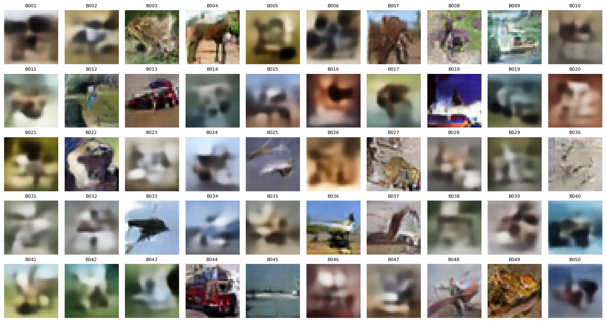

```
Phase A, page 2/4
```

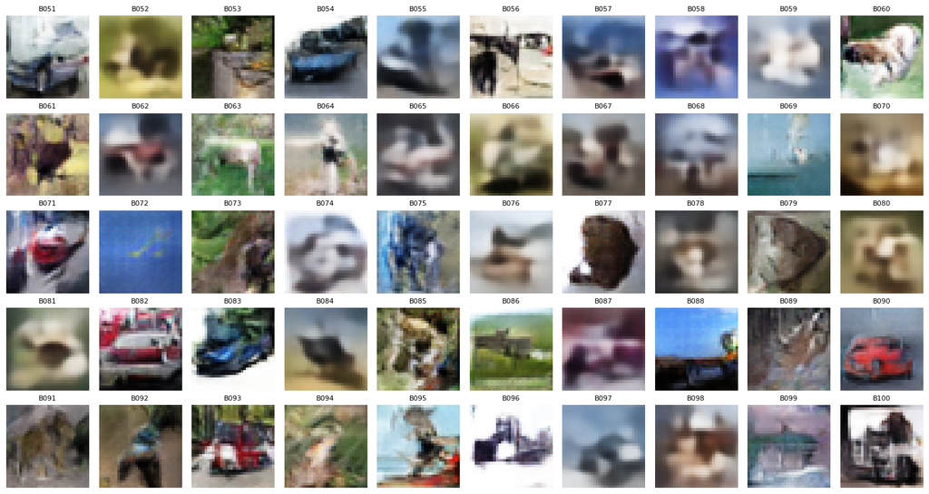

```
Phase A, page 3/4
```

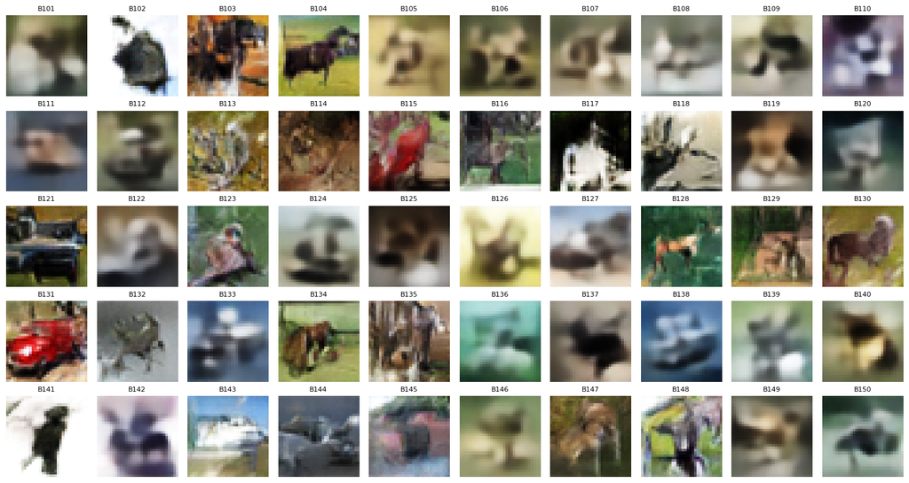

```
Phase A, page 4/4
```

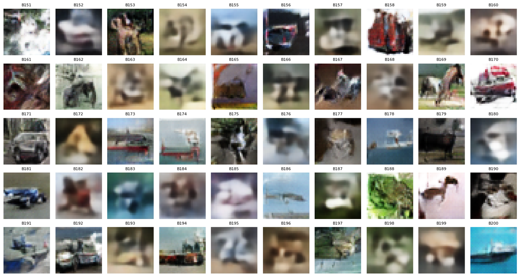

```python
def show_blind_evaluation_page(
    images,
    blind_ids,
    page,
    images_per_page=50,
):
    start = page * images_per_page
    end = min(
        start + images_per_page,
        len(images),
    )

    page_images = images[start:end]
    page_ids = blind_ids[start:end]

    fig, axes = plt.subplots(
        5,
        10,
        figsize=(15, 8),
    )

    axes = axes.flatten()

    for ax, image, blind_id in zip(
        axes,
        page_images,
        page_ids,
    ):
        ax.imshow(image)
        ax.set_title(
            blind_id,
            fontsize=8,
        )
        ax.axis("off")

    for ax in axes[len(page_images):]:
        ax.axis("off")

    plt.tight_layout()
    plt.show()


blind_ids = human_evaluation_df[
    "Blind ID"
].to_numpy()

for page in range(4):
    print(
        f"Phase A, page {page + 1}/4"
    )
    show_blind_evaluation_page(
        human_blind_images,
        blind_ids,
        page=page,
    )
```

```python
# Phase A: locked blinded visual-quality ratings

assert len(human_evaluation_df) == 200

expected_blind_ids = [
    f"B{i:03d}"
    for i in range(1, 201)
]

assert (
    human_evaluation_df["Blind ID"].tolist()
    == expected_blind_ids
)

# Strict scoring:
# C = Clear
# M = Marginal
# N = Nonsense
#
# Clear:
# confidently recognisable CIFAR-10-like object/class cues.
#
# Marginal:
# plausible object cues remain, but class identity is uncertain,
# blurry, distorted, incomplete, or background-dominated.
#
# Nonsense:
# no defensible coherent object/class interpretation.

phase_a_quality_codes = [
    # B001-B010
    "N", "M", "C", "C", "N", "N", "C", "M", "M", "M",

    # B011-B020
    "M", "M", "C", "M", "M", "N", "M", "M", "M", "N",

    # B021-B030
    "M", "M", "N", "M", "C", "M", "M", "M", "N", "N",

    # B031-B040
    "N", "N", "C", "M", "M", "C", "M", "N", "M", "M",

    # B041-B050
    "M", "M", "M", "C", "C", "N", "M", "C", "C", "M",

    # B051-B060
    "C", "N", "M", "C", "M", "M", "M", "N", "N", "C",

    # B061-B070
    "C", "M", "M", "M", "M", "M", "N", "M", "C", "N",

    # B071-B080
    "C", "N", "M", "M", "M", "M", "M", "N", "M", "M",

    # B081-B090
    "M", "C", "C", "M", "M", "M", "N", "M", "M", "C",

    # B091-B100
    "M", "M", "C", "M", "M", "N", "M", "M", "M", "M",

    # B101-B110
    "N", "M", "M", "M", "M", "N", "M", "M", "M", "N",

    # B111-B120
    "M", "M", "M", "M", "C", "M", "M", "M", "M", "M",

    # B121-B130
    "C", "M", "C", "M", "N", "M", "M", "C", "C", "M",

    # B131-B140
    "C", "M", "M", "C", "C", "N", "M", "M", "M", "M",

    # B141-B150
    "M", "N", "C", "C", "M", "M", "C", "M", "N", "M",

    # B151-B160
    "N", "M", "C", "N", "M", "C", "M", "C", "M", "M",

    # B161-B170
    "N", "M", "M", "M", "M", "M", "C", "M", "C", "C",

    # B171-B180
    "C", "N", "C", "C", "M", "M", "C", "C", "M", "M",

    # B181-B190
    "C", "M", "M", "M", "N", "C", "M", "M", "C", "C",

    # B191-B200
    "M", "C", "M", "C", "M", "M", "M", "M", "N", "C",
]

assert len(phase_a_quality_codes) == 200

quality_code_to_label = {
    "C": "Clear",
    "M": "Marginal",
    "N": "Nonsense",
}

human_evaluation_df["Quality rating"] = [
    quality_code_to_label[code]
    for code in phase_a_quality_codes
]

# Validate the complete scoring package.
assert (
    human_evaluation_df["Quality rating"]
    .isin(
        [
            "Clear",
            "Marginal",
            "Nonsense",
        ]
    )
    .all()
)

phase_a_counts = (
    human_evaluation_df["Quality rating"]
    .value_counts()
    .reindex(
        [
            "Clear",
            "Marginal",
            "Nonsense",
        ],
        fill_value=0,
    )
)

assert int(phase_a_counts.sum()) == 200
assert int(phase_a_counts["Clear"]) == 50
assert int(phase_a_counts["Marginal"]) == 116
assert int(phase_a_counts["Nonsense"]) == 34

phase_a_summary = pd.DataFrame(
    {
        "Rating": phase_a_counts.index,
        "Count": phase_a_counts.values,
        "Percentage": (
            phase_a_counts.values
            / len(human_evaluation_df)
            * 100.0
        ),
    }
)

# Preserve a frozen copy before revealing any requested labels.
phase_a_blind_scores = (
    human_evaluation_df[
        [
            "Blind ID",
            "Quality rating",
        ]
    ]
    .copy()
)

PHASE_A_QUALITY_FROZEN = True

display(phase_a_summary)

print(
    "Phase A scored images:",
    len(phase_a_blind_scores),
)
print(
    "Phase A quality scoring: FROZEN"
)
print(
    "Requested classes revealed during Phase A:",
    False,
)
print(
    "Model identities revealed during Phase A:",
    False,
)
```

|  | Rating | Count | Percentage |
| --- | --- | --- | --- |
| 0 | Clear | 50 | 25.0 |
| 1 | Marginal | 116 | 58.0 |
| 2 | Nonsense | 34 | 17.0 |

```
Phase A scored images: 200
Phase A quality scoring: FROZEN
Requested classes revealed during Phase A: False
Model identities revealed during Phase A: False
```

### 6.2 Phase B: Requested-Class Adherence

Phase A visual-quality ratings are now frozen.

For Phase B, the requested CIFAR-10 class is revealed for each anonymous image while model identity remains hidden.

Each image receives exactly one adherence rating:

- **Correct**: the requested class is clearly the most defensible interpretation.
- **Ambiguous**: the requested class is plausible, but the visual evidence is weak or another class is also reasonably plausible.
- **Incorrect**: the image more strongly resembles another class, or provides no meaningful evidence for the requested class.

This judgement is separate from visual quality. A low-quality image may still show some requested-class structure, while a visually recognisable image may depict the wrong requested class.

```python
# Phase B: reveal requested class, keep model hidden

assert PHASE_A_QUALITY_FROZEN is True
assert len(human_blind_requested_class_ids) == 200
assert len(human_blind_model_identity) == 200

phase_b_requested_class_names = np.array(
    [
        CLASS_NAMES[class_id]
        for class_id in human_blind_requested_class_ids
    ]
)

phase_b_display_df = pd.DataFrame(
    {
        "Blind ID": human_evaluation_df["Blind ID"],
        "Requested class": phase_b_requested_class_names,
        "Class-adherence rating": "",
    }
)

assert len(phase_b_display_df) == 200

display(
    phase_b_display_df.head(10)
)

print("Phase A quality scoring frozen:", PHASE_A_QUALITY_FROZEN)
print("Requested classes revealed for Phase B:", True)
print("Model identities revealed for Phase B:", False)
```

|  | Blind ID | Requested class | Class-adherence rating |
| --- | --- | --- | --- |
| 0 | B001 | Cat |  |
| 1 | B002 | Deer |  |
| 2 | B003 | Frog |  |
| 3 | B004 | Horse |  |
| 4 | B005 | Frog |  |
| 5 | B006 | Automobile |  |
| 6 | B007 | Horse |  |
| 7 | B008 | Bird |  |
| 8 | B009 | Ship |  |
| 9 | B010 | Horse |  |

```
Phase A quality scoring frozen: True
Requested classes revealed for Phase B: True
Model identities revealed for Phase B: False
```

```
Phase B, page 1/4
```

[figure not shown]

```
Phase B, page 2/4
```

[figure not shown]

```
Phase B, page 3/4
```

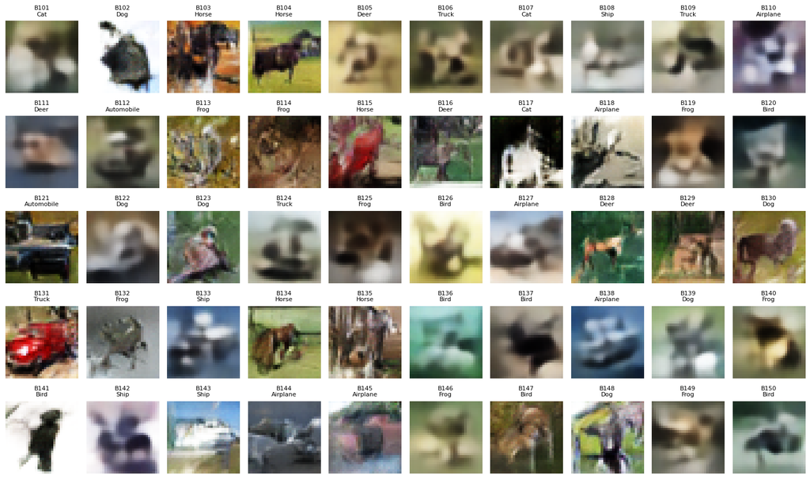

```
Phase B, page 4/4
```

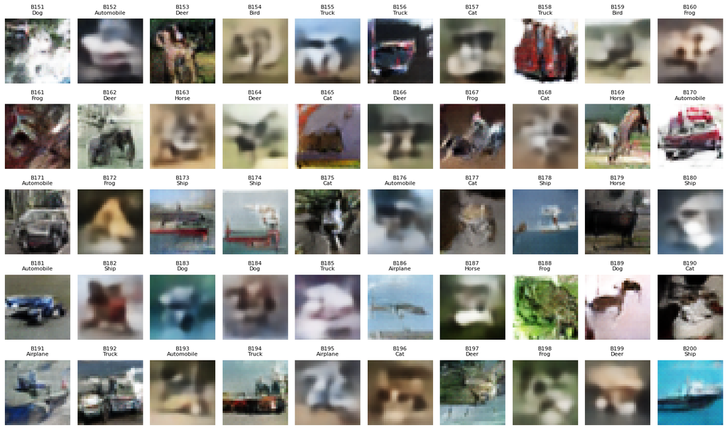

```python
def show_phase_b_page(
    images,
    blind_ids,
    requested_classes,
    page,
    images_per_page=50,
):
    start = page * images_per_page
    end = min(
        start + images_per_page,
        len(images),
    )

    page_images = images[start:end]
    page_ids = blind_ids[start:end]
    page_classes = requested_classes[start:end]

    fig, axes = plt.subplots(
        5,
        10,
        figsize=(15, 9),
    )

    axes = axes.flatten()

    for ax, image, blind_id, requested_class in zip(
        axes,
        page_images,
        page_ids,
        page_classes,
    ):
        ax.imshow(image)

        ax.set_title(
            f"{blind_id}\n{requested_class}",
            fontsize=8,
        )

        ax.axis("off")

    for ax in axes[len(page_images):]:
        ax.axis("off")

    plt.tight_layout()
    plt.show()


blind_ids = human_evaluation_df[
    "Blind ID"
].to_numpy()

for page in range(4):
    print(
        f"Phase B, page {page + 1}/4"
    )

    show_phase_b_page(
        human_blind_images,
        blind_ids,
        phase_b_requested_class_names,
        page=page,
    )
```

```python
# Phase B: locked requested-class adherence ratings

assert PHASE_A_QUALITY_FROZEN is True
assert len(human_evaluation_df) == 200

expected_blind_ids = [
    f"B{i:03d}"
    for i in range(1, 201)
]

assert (
    human_evaluation_df["Blind ID"].tolist()
    == expected_blind_ids
)

# C = Correct
# A = Ambiguous
# I = Incorrect

phase_b_adherence_codes = [
    # B001-B010
    "I", "I", "A", "C", "I", "I", "C", "I", "A", "A",

    # B011-B020
    "A", "A", "C", "I", "A", "I", "A", "I", "A", "I",

    # B021-B030
    "A", "A", "I", "A", "C", "A", "A", "A", "I", "I",

    # B031-B040
    "I", "I", "C", "A", "A", "I", "A", "I", "A", "C",

    # B041-B050
    "A", "A", "A", "C", "C", "I", "A", "C", "C", "A",

    # B051-B060
    "C", "I", "A", "C", "A", "C", "A", "I", "I", "C",

    # B061-B070
    "C", "A", "C", "A", "A", "A", "I", "A", "C", "I",

    # B071-B080
    "I", "I", "A", "A", "A", "A", "I", "I", "A", "A",

    # B081-B090
    "A", "C", "C", "A", "A", "I", "I", "C", "A", "C",

    # B091-B100
    "A", "C", "C", "A", "I", "I", "A", "A", "C", "I",

    # B101-B110
    "I", "A", "A", "C", "A", "I", "A", "A", "A", "I",

    # B111-B120
    "A", "A", "A", "A", "I", "A", "A", "I", "A", "A",

    # B121-B130
    "C", "A", "I", "I", "I", "A", "A", "C", "C", "A",

    # B131-B140
    "I", "I", "A", "C", "C", "I", "A", "A", "A", "A",

    # B141-B150
    "C", "I", "C", "C", "I", "A", "A", "I", "I", "A",

    # B151-B160
    "I", "A", "C", "I", "I", "C", "A", "C", "A", "A",

    # B161-B170
    "I", "A", "A", "A", "A", "A", "I", "A", "C", "C",

    # B171-B180
    "C", "I", "C", "C", "C", "A", "C", "C", "A", "A",

    # B181-B190
    "C", "A", "I", "A", "I", "C", "A", "I", "C", "C",

    # B191-B200
    "A", "A", "A", "A", "A", "A", "A", "A", "I", "C",
]

assert len(phase_b_adherence_codes) == 200

adherence_code_to_label = {
    "C": "Correct",
    "A": "Ambiguous",
    "I": "Incorrect",
}

human_evaluation_df[
    "Class-adherence rating"
] = [
    adherence_code_to_label[code]
    for code in phase_b_adherence_codes
]

assert (
    human_evaluation_df[
        "Class-adherence rating"
    ]
    .isin(
        [
            "Correct",
            "Ambiguous",
            "Incorrect",
        ]
    )
    .all()
)

# Consistency check:
# an image frozen as Nonsense in Phase A cannot be
# Correct or Ambiguous in Phase B.
phase_a_nonsense_mask = (
    human_evaluation_df[
        "Quality rating"
    ]
    == "Nonsense"
)

assert (
    human_evaluation_df.loc[
        phase_a_nonsense_mask,
        "Class-adherence rating",
    ]
    == "Incorrect"
).all()

phase_b_counts = (
    human_evaluation_df[
        "Class-adherence rating"
    ]
    .value_counts()
    .reindex(
        [
            "Correct",
            "Ambiguous",
            "Incorrect",
        ],
        fill_value=0,
    )
)

assert int(phase_b_counts.sum()) == 200
assert int(phase_b_counts["Correct"]) == 49
assert int(phase_b_counts["Ambiguous"]) == 95
assert int(phase_b_counts["Incorrect"]) == 56

phase_b_summary = pd.DataFrame(
    {
        "Rating": phase_b_counts.index,
        "Count": phase_b_counts.values,
        "Percentage": (
            phase_b_counts.values
            / len(human_evaluation_df)
            * 100.0
        ),
    }
)

phase_b_blind_scores = (
    human_evaluation_df[
        [
            "Blind ID",
            "Quality rating",
            "Class-adherence rating",
        ]
    ]
    .copy()
)

PHASE_B_ADHERENCE_FROZEN = True

display(phase_b_summary)

print(
    "Phase B scored images:",
    len(phase_b_blind_scores),
)
print(
    "Phase B adherence scoring: FROZEN"
)
print(
    "Model identities revealed during Phase B:",
    False,
)
```

|  | Rating | Count | Percentage |
| --- | --- | --- | --- |
| 0 | Correct | 49 | 24.5 |
| 1 | Ambiguous | 95 | 47.5 |
| 2 | Incorrect | 56 | 28.0 |

```
Phase B scored images: 200
Phase B adherence scoring: FROZEN
Model identities revealed during Phase B: False
```

### 6.3 Unmasked Human-Evaluation Results

Both scoring phases were completed and frozen before model identity was revealed.

The anonymous image IDs are now mapped back to their source models. This allows visual quality and requested-class adherence to be compared between the frozen GAN and VAE without changing any individual rating after unmasking.

Because each model contributed exactly 100 images, counts can also be interpreted directly as percentages.

```python
# Unmask model identity after both scoring phases are frozen

assert PHASE_A_QUALITY_FROZEN is True
assert PHASE_B_ADHERENCE_FROZEN is True

assert len(human_blind_model_identity) == 200
assert len(phase_b_requested_class_names) == 200

human_unmasked_df = human_evaluation_df.copy()

human_unmasked_df["Requested class"] = (
    phase_b_requested_class_names
)

human_unmasked_df["Model"] = (
    human_blind_model_identity
)

assert set(
    human_unmasked_df["Model"].unique()
) == {"GAN", "VAE"}

assert (
    human_unmasked_df["Model"]
    .value_counts()
    .to_dict()
    == {
        "GAN": 100,
        "VAE": 100,
    }
)

# Per-model quality results

quality_order = [
    "Clear",
    "Marginal",
    "Nonsense",
]

adherence_order = [
    "Correct",
    "Ambiguous",
    "Incorrect",
]

quality_by_model = pd.crosstab(
    human_unmasked_df["Model"],
    human_unmasked_df["Quality rating"],
).reindex(
    index=["GAN", "VAE"],
    columns=quality_order,
    fill_value=0,
)

adherence_by_model = pd.crosstab(
    human_unmasked_df["Model"],
    human_unmasked_df["Class-adherence rating"],
).reindex(
    index=["GAN", "VAE"],
    columns=adherence_order,
    fill_value=0,
)

human_model_summary = pd.DataFrame(
    {
        "Model": ["GAN", "VAE"],

        "Clear": [
            quality_by_model.loc["GAN", "Clear"],
            quality_by_model.loc["VAE", "Clear"],
        ],

        "Marginal": [
            quality_by_model.loc["GAN", "Marginal"],
            quality_by_model.loc["VAE", "Marginal"],
        ],

        "Nonsense": [
            quality_by_model.loc["GAN", "Nonsense"],
            quality_by_model.loc["VAE", "Nonsense"],
        ],

        "Clear %": [
            quality_by_model.loc["GAN", "Clear"],
            quality_by_model.loc["VAE", "Clear"],
        ],

        "Correct": [
            adherence_by_model.loc["GAN", "Correct"],
            adherence_by_model.loc["VAE", "Correct"],
        ],

        "Ambiguous": [
            adherence_by_model.loc["GAN", "Ambiguous"],
            adherence_by_model.loc["VAE", "Ambiguous"],
        ],

        "Incorrect": [
            adherence_by_model.loc["GAN", "Incorrect"],
            adherence_by_model.loc["VAE", "Incorrect"],
        ],

        "Correct %": [
            adherence_by_model.loc["GAN", "Correct"],
            adherence_by_model.loc["VAE", "Correct"],
        ],
    }
)

display(human_model_summary)

print("Model identities revealed: YES")
print("Scores changed after unmasking: NO")
print("Human comparison unmasking: COMPLETE")
```

|  | Model | Clear | Marginal | Nonsense | Clear % | Correct | Ambiguous | Incorrect | Correct % |
| --- | --- | --- | --- | --- | --- | --- | --- | --- | --- |
| 0 | GAN | 50 | 45 | 5 | 50 | 48 | 30 | 22 | 48 |
| 1 | VAE | 0 | 71 | 29 | 0 | 1 | 65 | 34 | 1 |

```
Model identities revealed: YES
Scores changed after unmasking: NO
Human comparison unmasking: COMPLETE
```

```python
# Requested-class adherence by model and class

class_adherence_rows = []

for class_name in CLASS_NAMES:

    for model_name in ["GAN", "VAE"]:

        subset = human_unmasked_df[
            (
                human_unmasked_df["Model"]
                == model_name
            )
            &
            (
                human_unmasked_df["Requested class"]
                == class_name
            )
        ]

        assert len(subset) == HUMAN_IMAGES_PER_CLASS

        counts = (
            subset["Class-adherence rating"]
            .value_counts()
            .reindex(
                adherence_order,
                fill_value=0,
            )
        )

        class_adherence_rows.append(
            {
                "Model": model_name,
                "Requested class": class_name,
                "Correct": int(counts["Correct"]),
                "Ambiguous": int(counts["Ambiguous"]),
                "Incorrect": int(counts["Incorrect"]),
                "Correct %": float(
                    counts["Correct"]
                    / HUMAN_IMAGES_PER_CLASS
                    * 100
                ),
            }
        )

class_adherence_df = pd.DataFrame(
    class_adherence_rows
)

class_correct_comparison = (
    class_adherence_df.pivot(
        index="Requested class",
        columns="Model",
        values="Correct",
    )
    .reindex(CLASS_NAMES)
    .reset_index()
)

class_correct_comparison.columns = [
    "Requested class",
    "GAN Correct / 10",
    "VAE Correct / 10",
]

display(class_correct_comparison)
```

|  | Requested class | GAN Correct / 10 | VAE Correct / 10 |
| --- | --- | --- | --- |
| 0 | Airplane | 5 | 0 |
| 1 | Automobile | 10 | 0 |
| 2 | Bird | 2 | 0 |
| 3 | Cat | 3 | 0 |
| 4 | Deer | 5 | 0 |
| 5 | Dog | 2 | 0 |
| 6 | Frog | 1 | 0 |
| 7 | Horse | 7 | 0 |
| 8 | Ship | 8 | 1 |
| 9 | Truck | 5 | 0 |

### 6.4 Blind Human-Evaluation Interpretation

The fresh masked human evaluation strongly favours the GAN.

After model identity was revealed, the GAN accounted for all `50` Clear-rated images, giving **50% Clear, 45% Marginal and 5% Nonsense**. The VAE produced **0% Clear, 71% Marginal and 29% Nonsense**.

Requested-class adherence showed an even larger difference. The GAN received **48 Correct, 30 Ambiguous and 22 Incorrect** ratings, while the VAE received only **1 Correct, 65 Ambiguous and 34 Incorrect**.

These scores were fixed before model identity was revealed, so the model comparison did not influence the individual ratings.

The adherence result also shows why conditional generation quality should not be assessed using image quality alone. Some generated images contained plausible object structure but did not convincingly represent the requested class.

The GAN's strongest fresh class-control results were for automobiles, ships and horses, while frogs, birds and dogs were more difficult in this 10-image-per-class sample. These class-level results are descriptive because each class contains only ten images.

The fresh human evidence therefore agrees with the protected-test FID result: the GAN is substantially stronger than V04 for the image-generation objective. However, final model selection remains deferred until the formal memorisation audit is completed.

A limitation is that the manual evaluation used one scorer. Model-identity masking, fixed criteria and freezing ratings before unmasking reduce avoidable bias, but they do not eliminate scorer subjectivity.

## 7. Formal Memorisation Audit

FID evaluates overall feature-distribution similarity, but does not determine whether individual generated images are unusually close to particular training examples.

The final memorisation audit therefore compares nearest-training-image distances for three groups:

- all `10,000` unseen CIFAR-10 test images;
- `5,000` frozen GAN images from final FID seed `2001`;
- `5,000` frozen VAE images from final FID seed `2001`.

All groups use the same `50,000` CIFAR-10 training images as the reference bank.

The previously frozen protocol uses:

- the same InceptionV3 average-pooling features used for FID;
- `2,048` features per image;
- L2-normalised feature vectors;
- cosine distance;
- one identical exact nearest-neighbour procedure for test, GAN and VAE.

The official test-to-training distribution provides a natural unseen-real baseline. Generated images that are substantially closer to the training set than genuine unseen images warrant closer inspection, but unusually small distance alone does not prove memorisation.

### 7.1 Training Feature Bank

The full `50,000`-image CIFAR-10 training set is passed through the same frozen InceptionV3 feature extractor already used in Section 5.

This feature bank represents the images that were available during model training.

No model inference, tuning or training occurs in this step.

```python
# Training-set Inception feature bank

assert PROTECTED_TEST_ACCESSED_IN_NOTEBOOK4 is True
assert FINAL_PROTOCOL_FROZEN is True

assert cifar10_train_images.shape == (
    MEMORISATION_TRAIN_REFERENCE_COUNT,
    32,
    32,
    3,
)

print(
    "Extracting Inception features from all",
    f"{MEMORISATION_TRAIN_REFERENCE_COUNT:,}",
    "training images..."
)

train_inception_features = (
    extract_inception_features(
        cifar10_train_images,
        fid_feature_extractor,
    )
)

assert train_inception_features.shape == (
    MEMORISATION_TRAIN_REFERENCE_COUNT,
    INCEPTION_FEATURE_DIM,
)

assert np.isfinite(
    train_inception_features
).all()

print("\nTraining feature bank: READY")
print(
    "Images:",
    f"{MEMORISATION_TRAIN_REFERENCE_COUNT:,}",
)
print(
    "Feature matrix:",
    train_inception_features.shape,
)
print(
    "Feature dtype:",
    train_inception_features.dtype,
)
print(
    "Finite features:",
    bool(
        np.isfinite(
            train_inception_features
        ).all()
    ),
)
```

```
Extracting Inception features from all 50,000 training images...

Training feature bank: READY
Images: 50,000
Feature matrix: (50000, 2048)
Feature dtype: float64
Finite features: True
```

### 7.2 Shared Cosine-Distance Representation

Raw Inception features are L2-normalised before nearest-neighbour comparison.

For two L2-normalised feature vectors, cosine distance is:

`1 − cosine similarity`

Lower distance means greater feature-space similarity.

The same exact implementation is used for the unseen-real baseline and both generated-image groups.

```python
# L2-normalised feature representation

def l2_normalise_features(features):
    features = np.asarray(
        features,
        dtype=np.float32,
    )

    norms = np.linalg.norm(
        features,
        axis=1,
        keepdims=True,
    )

    assert np.all(norms > 0.0)

    normalised = features / norms

    assert np.isfinite(normalised).all()

    return normalised.astype(
        np.float32,
        copy=False,
    )


train_nn_features = l2_normalise_features(
    train_inception_features
)

test_nn_features = l2_normalise_features(
    test_inception_features
)

gan_nn_features = l2_normalise_features(
    gan_memorisation_features
)

vae_nn_features = l2_normalise_features(
    vae_memorisation_features
)

assert train_nn_features.shape == (
    50_000,
    2_048,
)

assert test_nn_features.shape == (
    10_000,
    2_048,
)

assert gan_nn_features.shape == (
    5_000,
    2_048,
)

assert vae_nn_features.shape == (
    5_000,
    2_048,
)

# The float64 training features are no longer needed after
# conversion to the compact float32 nearest-neighbour bank.
del train_inception_features

print("Nearest-neighbour representations: READY")
print("Training bank:", train_nn_features.shape)
print("Test baseline:", test_nn_features.shape)
print("GAN audit pool:", gan_nn_features.shape)
print("VAE audit pool:", vae_nn_features.shape)
print(
    "Feature dtype:",
    train_nn_features.dtype,
)
print(
    "Distance metric:",
    MEMORISATION_DISTANCE,
)
```

```
Nearest-neighbour representations: READY
Training bank: (50000, 2048)
Test baseline: (10000, 2048)
GAN audit pool: (5000, 2048)
VAE audit pool: (5000, 2048)
Feature dtype: float32
Distance metric: cosine
```

```python
# Exact nearest-training-neighbour search

NN_QUERY_BATCH_SIZE = 256

# Exact nearest neighbours for L2-normalised features.
# For normalised vectors:
# cosine distance = 1 - dot product

# Returns:
# nearest_distances
# nearest_reference_indices
def exact_cosine_nearest_neighbours(
    query_features,
    reference_features,
    batch_size=NN_QUERY_BATCH_SIZE,
):

    query_features = np.asarray(
        query_features,
        dtype=np.float32,
    )

    reference_features = np.asarray(
        reference_features,
        dtype=np.float32,
    )

    assert query_features.ndim == 2
    assert reference_features.ndim == 2

    assert (
        query_features.shape[1]
        == reference_features.shape[1]
        == INCEPTION_FEATURE_DIM
    )

    reference_tensor = tf.convert_to_tensor(
        reference_features,
        dtype=tf.float32,
    )

    all_distances = []
    all_indices = []

    for start in range(
        0,
        len(query_features),
        batch_size,
    ):
        end = min(
            start + batch_size,
            len(query_features),
        )

        query_tensor = tf.convert_to_tensor(
            query_features[start:end],
            dtype=tf.float32,
        )

        similarities = tf.linalg.matmul(
            query_tensor,
            reference_tensor,
            transpose_b=True,
        )

        nearest_similarity = tf.reduce_max(
            similarities,
            axis=1,
        )

        nearest_index = tf.argmax(
            similarities,
            axis=1,
            output_type=tf.int32,
        )

        nearest_distance = (
            1.0 - nearest_similarity
        )

        nearest_distance = tf.clip_by_value(
            nearest_distance,
            0.0,
            2.0,
        )

        all_distances.append(
            nearest_distance.numpy()
        )

        all_indices.append(
            nearest_index.numpy()
        )

        del similarities

    distances = np.concatenate(
        all_distances
    ).astype(np.float32)

    indices = np.concatenate(
        all_indices
    ).astype(np.int32)

    assert distances.shape == (
        len(query_features),
    )

    assert indices.shape == (
        len(query_features),
    )

    assert np.isfinite(distances).all()

    return distances, indices


print(
    "Exact cosine nearest-neighbour search: READY"
)
print(
    "Query batch size:",
    NN_QUERY_BATCH_SIZE,
)
```

```
Exact cosine nearest-neighbour search: READY
Query batch size: 256
```

### 7.3 Test-to-Training Baseline

The complete official test set is first compared with the training feature bank.

This provides the reference distribution for how close genuine unseen CIFAR-10 images naturally lie to the training set.

### 7.4 GAN- and VAE-to-Training Distances

The retained seed-`2001` GAN and VAE generation pools are then evaluated using exactly the same nearest-neighbour procedure.

```python
# Test -> training baseline
# GAN  -> training
# VAE  -> training

print("1/3 Test -> training nearest neighbours")

(
    test_to_train_distances,
    test_to_train_indices,
) = exact_cosine_nearest_neighbours(
    test_nn_features,
    train_nn_features,
)

print(
    "Test baseline complete:",
    len(test_to_train_distances),
)


print("\n2/3 GAN -> training nearest neighbours")

(
    gan_to_train_distances,
    gan_to_train_indices,
) = exact_cosine_nearest_neighbours(
    gan_nn_features,
    train_nn_features,
)

print(
    "GAN audit complete:",
    len(gan_to_train_distances),
)


print("\n3/3 VAE -> training nearest neighbours")

(
    vae_to_train_distances,
    vae_to_train_indices,
) = exact_cosine_nearest_neighbours(
    vae_nn_features,
    train_nn_features,
)

print(
    "VAE audit complete:",
    len(vae_to_train_distances),
)

assert len(
    test_to_train_distances
) == MEMORISATION_TEST_BASELINE_COUNT

assert len(
    gan_to_train_distances
) == MEMORISATION_GENERATED_COUNT

assert len(
    vae_to_train_distances
) == MEMORISATION_GENERATED_COUNT

print(
    "\nAll three nearest-neighbour searches: COMPLETE"
)
```

```
1/3 Test -> training nearest neighbours
Test baseline complete: 10000

2/3 GAN -> training nearest neighbours
GAN audit complete: 5000

3/3 VAE -> training nearest neighbours
VAE audit complete: 5000

All three nearest-neighbour searches: COMPLETE
```

### 7.5 Nearest-Neighbour Distance Summary

The nearest-training-image distance distributions are summarised using the mean, median, interquartile range and lower-tail percentiles.

The lower tail is especially relevant because potential memorisation would appear as generated images lying unusually close to particular training examples.

Rather than introducing an arbitrary similarity threshold, the unseen-real test distribution provides the baseline. The proportions of GAN and VAE samples falling at or below the test-set 5th and 1st percentile distances are therefore reported directly.

A generated distribution that is substantially shifted toward smaller distances than the test baseline would warrant closer inspection.

```python
# Distance-distribution summaries

def summarise_nn_distances(
    group_name,
    distances,
):
    distances = np.asarray(
        distances,
        dtype=np.float64,
    )

    return {
        "Group": group_name,
        "N": len(distances),
        "Mean": np.mean(distances),
        "Median": np.median(distances),
        "Q1": np.percentile(
            distances,
            25,
        ),
        "Q3": np.percentile(
            distances,
            75,
        ),
        "5th percentile": np.percentile(
            distances,
            5,
        ),
        "1st percentile": np.percentile(
            distances,
            1,
        ),
        "Minimum": np.min(distances),
    }


memorisation_distance_summary = pd.DataFrame(
    [
        summarise_nn_distances(
            "Test -> training",
            test_to_train_distances,
        ),
        summarise_nn_distances(
            "GAN -> training",
            gan_to_train_distances,
        ),
        summarise_nn_distances(
            "VAE -> training",
            vae_to_train_distances,
        ),
    ]
)

display(
    memorisation_distance_summary.round(6)
)

TEST_DISTANCE_P05 = float(
    np.percentile(
        test_to_train_distances,
        5,
    )
)

TEST_DISTANCE_P01 = float(
    np.percentile(
        test_to_train_distances,
        1,
    )
)


def proportion_at_or_below(
    distances,
    threshold,
):
    return float(
        np.mean(
            np.asarray(distances)
            <= threshold
        )
    )


tail_comparison_table = pd.DataFrame(
    [
        {
            "Group": "Test baseline",
            "<= test 5th percentile": (
                proportion_at_or_below(
                    test_to_train_distances,
                    TEST_DISTANCE_P05,
                )
                * 100
            ),
            "<= test 1st percentile": (
                proportion_at_or_below(
                    test_to_train_distances,
                    TEST_DISTANCE_P01,
                )
                * 100
            ),
        },
        {
            "Group": "GAN",
            "<= test 5th percentile": (
                proportion_at_or_below(
                    gan_to_train_distances,
                    TEST_DISTANCE_P05,
                )
                * 100
            ),
            "<= test 1st percentile": (
                proportion_at_or_below(
                    gan_to_train_distances,
                    TEST_DISTANCE_P01,
                )
                * 100
            ),
        },
        {
            "Group": "VAE",
            "<= test 5th percentile": (
                proportion_at_or_below(
                    vae_to_train_distances,
                    TEST_DISTANCE_P05,
                )
                * 100
            ),
            "<= test 1st percentile": (
                proportion_at_or_below(
                    vae_to_train_distances,
                    TEST_DISTANCE_P01,
                )
                * 100
            ),
        },
    ]
)

display(
    tail_comparison_table.round(2)
)
```

|  | Group | N | Mean | Median | Q1 | Q3 | 5th percentile | 1st percentile | Minimum |
| --- | --- | --- | --- | --- | --- | --- | --- | --- | --- |
| 0 | Test -> training | 10000 | 0.147069 | 0.149454 | 0.116976 | 0.177869 | 0.074740 | 0.042734 | 0.015577 |
| 1 | GAN -> training | 5000 | 0.183176 | 0.185561 | 0.162485 | 0.205092 | 0.125854 | 0.106012 | 0.078671 |
| 2 | VAE -> training | 5000 | 0.178364 | 0.177739 | 0.163023 | 0.192648 | 0.143362 | 0.132218 | 0.092704 |

|  | Group | <= test 5th percentile | <= test 1st percentile |
| --- | --- | --- | --- |
| 0 | Test baseline | 5.0 | 1.0 |
| 1 | GAN | 0.0 | 0.0 |
| 2 | VAE | 0.0 | 0.0 |

### 7.6 Nearest-Training-Image Reuse

Nearest-neighbour distance alone does not show whether many generated images repeatedly map to the same training examples.

This section therefore measures:

- the number of unique training images selected as nearest neighbours;
- duplicate nearest-neighbour assignments;
- how many training images are reused at least twice;
- the maximum number of generated images assigned to any single training neighbour.

High reuse does not by itself demonstrate memorisation. In particular, repeated assignment can also reflect low generated diversity or concentration around a limited set of visual modes.

The reuse results are therefore interpreted together with the actual nearest-neighbour distances and later visual inspection of the closest pairs.

```python
# Nearest-training-image reuse

def summarise_neighbour_reuse(
    group_name,
    neighbour_indices,
):
    neighbour_indices = np.asarray(
        neighbour_indices
    )

    unique_indices, counts = np.unique(
        neighbour_indices,
        return_counts=True,
    )

    duplicate_assignments = (
        len(neighbour_indices)
        - len(unique_indices)
    )

    return {
        "Group": group_name,
        "Queries": len(neighbour_indices),
        "Unique training neighbours": (
            len(unique_indices)
        ),
        "Duplicate assignments": (
            duplicate_assignments
        ),
        "Duplicate-assignment %": (
            duplicate_assignments
            / len(neighbour_indices)
            * 100
        ),
        "Training neighbours reused >=2 times": int(
            np.sum(counts >= 2)
        ),
        "Maximum reuse count": int(
            np.max(counts)
        ),
    }


neighbour_reuse_table = pd.DataFrame(
    [
        summarise_neighbour_reuse(
            "Test baseline",
            test_to_train_indices,
        ),
        summarise_neighbour_reuse(
            "GAN",
            gan_to_train_indices,
        ),
        summarise_neighbour_reuse(
            "VAE",
            vae_to_train_indices,
        ),
    ]
)

display(
    neighbour_reuse_table.round(2)
)
```

|  | Group | Queries | Unique training neighbours | Duplicate assignments | Duplicate-assignment % | Training neighbours reused >=2 times | Maximum reuse count |
| --- | --- | --- | --- | --- | --- | --- | --- |
| 0 | Test baseline | 10000 | 8310 | 1690 | 16.90 | 1355 | 6 |
| 1 | GAN | 5000 | 3595 | 1405 | 28.10 | 808 | 22 |
| 2 | VAE | 5000 | 1006 | 3994 | 79.88 | 493 | 124 |

### 7.7 Nearest-Neighbour Distance Distribution

An empirical cumulative distribution function (ECDF) provides a direct visual comparison of the complete nearest-training-distance distributions.

For any cosine-distance value on the horizontal axis, the vertical axis shows the proportion of images whose nearest training example lies at or below that distance.

A curve shifted further left indicates generally smaller nearest-training distances.

The official test-to-training curve acts as the unseen-real reference. The generated distributions are interpreted relative to this baseline rather than against an arbitrary absolute distance threshold.

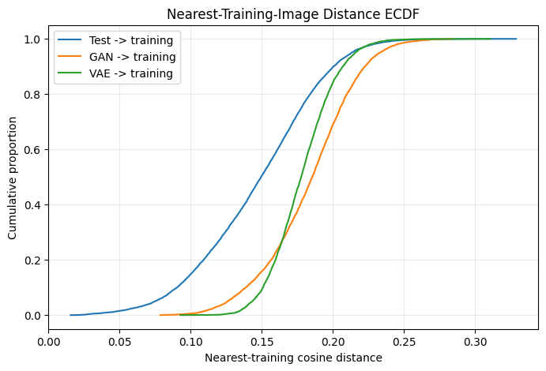

```python
# Nearest-neighbour distance ECDF

def ecdf(values):
    values = np.sort(
        np.asarray(values)
    )

    probabilities = (
        np.arange(
            1,
            len(values) + 1,
        )
        / len(values)
    )

    return values, probabilities


plt.figure(
    figsize=(8, 5)
)

for label, distances in [
    (
        "Test -> training",
        test_to_train_distances,
    ),
    (
        "GAN -> training",
        gan_to_train_distances,
    ),
    (
        "VAE -> training",
        vae_to_train_distances,
    ),
]:
    x, y = ecdf(
        distances
    )

    plt.plot(
        x,
        y,
        label=label,
    )

plt.xlabel(
    "Nearest-training cosine distance"
)

plt.ylabel(
    "Cumulative proportion"
)

plt.title(
    "Nearest-Training-Image Distance ECDF"
)

plt.legend()

plt.grid(
    alpha=0.25
)

plt.show()
```

### 7.8 Distribution-Level Memorisation Findings

The distribution-level results do not indicate suspicious training-set proximity for either frozen generator.

The unseen-real CIFAR-10 test images were naturally closer to the training set than either generated group. Their median nearest-training cosine distance was `0.149454`, compared with `0.185561` for the GAN and `0.177739` for the VAE.

The lower tail provides even stronger evidence. The test baseline 5th-percentile distance was `0.074740` and its 1st-percentile distance was `0.042734`. None of the `5,000` GAN samples and none of the `5,000` VAE samples fell at or below either threshold.

The nearest-neighbour reuse results reveal a separate difference in diversity. The GAN's `5,000` samples mapped to `3,595` unique training neighbours, whereas the VAE mapped to only `1,006`. The VAE also showed a much larger duplicate-assignment rate (`79.88%`) and maximum reuse count (`124`) than the GAN (`28.10%` and `22` respectively).

Because the VAE's nearest-neighbour distances are not unusually small, this high reuse is more consistent with generated-image concentration or limited diversity than with direct training-image memorisation.

These distribution-level findings are reassuring, but the closest generated-training pairs are still inspected visually before the memorisation audit is concluded.

### 7.9 Closest Generated–Training Pair Inspection

The distribution-level audit found no generated samples below the unseen-real test baseline's 5th- or 1st-percentile nearest-neighbour distances.

As a final qualitative check, the `20` generated images with the smallest training-set cosine distances are inspected for each model.

Each displayed pair contains:

- the generated image;
- its exact nearest training image under the frozen feature-space search;
- the cosine distance between them;
- the requested generated class;
- the true CIFAR-10 class of the nearest training image.

Visual resemblance is interpreted cautiously. Similar pose, colour, background, or object structure can produce close feature-space matches without implying that an image was copied.

A close-looking pair is therefore supporting evidence only. Memorisation would be more concerning if the generated image reproduced unusually specific training-image content and also showed abnormally small feature distance relative to the unseen-real baseline.

```python
# 20 closest generated -> training pairs per model

CLOSEST_PAIR_COUNT = 20

gan_closest_generated_indices = np.argsort(
    gan_to_train_distances
)[:CLOSEST_PAIR_COUNT]

vae_closest_generated_indices = np.argsort(
    vae_to_train_distances
)[:CLOSEST_PAIR_COUNT]


def build_closest_pair_table(
    model_name,
    generated_indices,
    nearest_training_indices,
    distances,
    requested_classes,
):
    rows = []

    for rank, generated_index in enumerate(
        generated_indices,
        start=1,
    ):
        training_index = int(
            nearest_training_indices[
                generated_index
            ]
        )

        requested_class_id = int(
            requested_classes[
                generated_index
            ]
        )

        training_class_id = int(
            cifar10_train_labels[
                training_index
            ].reshape(-1)[0]
        )

        rows.append(
            {
                "Rank": rank,
                "Model": model_name,
                "Generated index": int(
                    generated_index
                ),
                "Requested class": (
                    CLASS_NAMES[
                        requested_class_id
                    ]
                ),
                "Nearest training index": (
                    training_index
                ),
                "Training class": (
                    CLASS_NAMES[
                        training_class_id
                    ]
                ),
                "Cosine distance": float(
                    distances[
                        generated_index
                    ]
                ),
            }
        )

    return pd.DataFrame(rows)


gan_closest_pairs_df = build_closest_pair_table(
    model_name="GAN",
    generated_indices=(
        gan_closest_generated_indices
    ),
    nearest_training_indices=(
        gan_to_train_indices
    ),
    distances=gan_to_train_distances,
    requested_classes=(
        gan_memorisation_requested_classes
    ),
)

vae_closest_pairs_df = build_closest_pair_table(
    model_name="VAE",
    generated_indices=(
        vae_closest_generated_indices
    ),
    nearest_training_indices=(
        vae_to_train_indices
    ),
    distances=vae_to_train_distances,
    requested_classes=(
        vae_memorisation_requested_classes
    ),
)

assert len(gan_closest_pairs_df) == 20
assert len(vae_closest_pairs_df) == 20

print("Closest GAN-training pairs:")
display(
    gan_closest_pairs_df.round(
        {"Cosine distance": 6}
    )
)

print("\nClosest VAE-training pairs:")
display(
    vae_closest_pairs_df.round(
        {"Cosine distance": 6}
    )
)
```

```
Closest GAN-training pairs:
```

|  | Rank | Model | Generated index | Requested class | Nearest training index | Training class | Cosine distance |
| --- | --- | --- | --- | --- | --- | --- | --- |
| 0 | 1 | GAN | 102 | Airplane | 5446 | Ship | 0.078671 |
| 1 | 2 | GAN | 588 | Automobile | 9535 | Automobile | 0.079791 |
| 2 | 3 | GAN | 4587 | Truck | 49147 | Truck | 0.080607 |
| 3 | 4 | GAN | 533 | Automobile | 22388 | Automobile | 0.081765 |
| 4 | 5 | GAN | 510 | Automobile | 41627 | Automobile | 0.084361 |
| 5 | 6 | GAN | 4520 | Truck | 44010 | Truck | 0.084844 |
| 6 | 7 | GAN | 4612 | Truck | 36102 | Automobile | 0.088045 |
| 7 | 8 | GAN | 3565 | Horse | 28528 | Horse | 0.088510 |
| 8 | 9 | GAN | 801 | Automobile | 16577 | Automobile | 0.089243 |
| 9 | 10 | GAN | 4635 | Truck | 883 | Truck | 0.089314 |
| 10 | 11 | GAN | 706 | Automobile | 12929 | Automobile | 0.091603 |
| 11 | 12 | GAN | 4425 | Ship | 48081 | Ship | 0.091727 |
| 12 | 13 | GAN | 4715 | Truck | 32337 | Truck | 0.092366 |
| 13 | 14 | GAN | 4245 | Ship | 48774 | Ship | 0.092695 |
| 14 | 15 | GAN | 4855 | Truck | 49766 | Truck | 0.093191 |
| 15 | 16 | GAN | 3640 | Horse | 13373 | Horse | 0.093195 |
| 16 | 17 | GAN | 4443 | Ship | 35661 | Ship | 0.093676 |
| 17 | 18 | GAN | 4551 | Truck | 25560 | Truck | 0.095689 |
| 18 | 19 | GAN | 3974 | Horse | 16565 | Horse | 0.096225 |
| 19 | 20 | GAN | 4920 | Truck | 31010 | Truck | 0.096486 |

```
Closest VAE-training pairs:
```

|  | Rank | Model | Generated index | Requested class | Nearest training index | Training class | Cosine distance |
| --- | --- | --- | --- | --- | --- | --- | --- |
| 0 | 1 | VAE | 4258 | Ship | 47083 | Truck | 0.092704 |
| 1 | 2 | VAE | 160 | Airplane | 9786 | Ship | 0.105798 |
| 2 | 3 | VAE | 3126 | Frog | 1351 | Cat | 0.106990 |
| 3 | 4 | VAE | 3308 | Frog | 31791 | Dog | 0.112039 |
| 4 | 5 | VAE | 3145 | Frog | 901 | Ship | 0.115447 |
| 5 | 6 | VAE | 3538 | Horse | 1657 | Deer | 0.117618 |
| 6 | 7 | VAE | 4475 | Ship | 41967 | Truck | 0.119223 |
| 7 | 8 | VAE | 4148 | Ship | 1714 | Truck | 0.120047 |
| 8 | 9 | VAE | 387 | Airplane | 39896 | Ship | 0.120872 |
| 9 | 10 | VAE | 1916 | Cat | 22779 | Dog | 0.121229 |
| 10 | 11 | VAE | 4929 | Truck | 25457 | Airplane | 0.121590 |
| 11 | 12 | VAE | 3607 | Horse | 40110 | Ship | 0.121616 |
| 12 | 13 | VAE | 3713 | Horse | 32119 | Deer | 0.122198 |
| 13 | 14 | VAE | 4950 | Truck | 47083 | Truck | 0.122448 |
| 14 | 15 | VAE | 4174 | Ship | 191 | Horse | 0.122830 |
| 15 | 16 | VAE | 1613 | Cat | 1351 | Cat | 0.123206 |
| 16 | 17 | VAE | 377 | Airplane | 38348 | Ship | 0.123518 |
| 17 | 18 | VAE | 954 | Automobile | 5271 | Truck | 0.123570 |
| 18 | 19 | VAE | 2971 | Dog | 15860 | Cat | 0.124502 |
| 19 | 20 | VAE | 329 | Airplane | 15860 | Cat | 0.124504 |

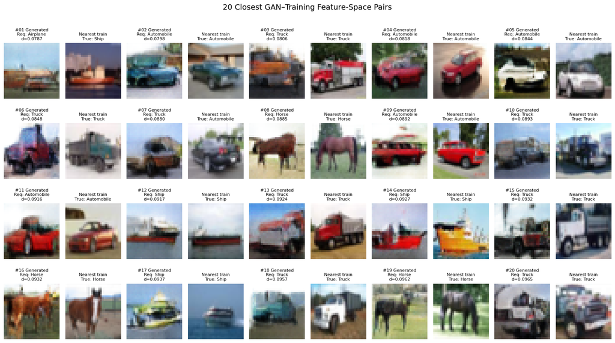

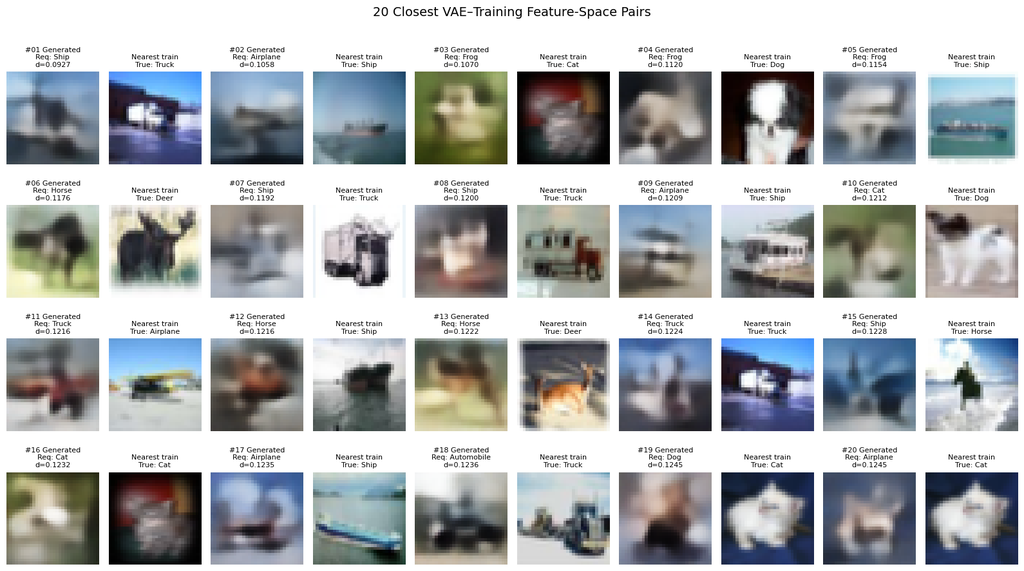

```python
# Closest-pair visual inspection

def show_closest_pair_grid(
    generated_images,
    pair_table,
    title,
):
    pairs_per_row = 5
    rows = 4

    fig, axes = plt.subplots(
        rows,
        pairs_per_row * 2,
        figsize=(16, 9),
    )

    axes = np.asarray(axes)

    for pair_position, row in (
        pair_table.reset_index(
            drop=True
        ).iterrows()
    ):
        grid_row = (
            pair_position
            // pairs_per_row
        )

        pair_column = (
            pair_position
            % pairs_per_row
        )

        generated_axis = axes[
            grid_row,
            pair_column * 2,
        ]

        training_axis = axes[
            grid_row,
            pair_column * 2 + 1,
        ]

        generated_index = int(
            row["Generated index"]
        )

        training_index = int(
            row["Nearest training index"]
        )

        distance = float(
            row["Cosine distance"]
        )

        generated_axis.imshow(
            generated_images[
                generated_index
            ]
        )

        generated_axis.set_title(
            (
                f"#{int(row['Rank']):02d} Generated\n"
                f"Req: {row['Requested class']}\n"
                f"d={distance:.4f}"
            ),
            fontsize=8,
        )

        generated_axis.axis("off")

        training_axis.imshow(
            cifar10_train_images[
                training_index
            ]
        )

        training_axis.set_title(
            (
                "Nearest train\n"
                f"True: {row['Training class']}"
            ),
            fontsize=8,
        )

        training_axis.axis("off")

    fig.suptitle(
        title,
        fontsize=14,
        y=1.01,
    )

    plt.tight_layout()
    plt.show()


show_closest_pair_grid(
    generated_images=(
        gan_memorisation_images
    ),
    pair_table=gan_closest_pairs_df,
    title=(
        "20 Closest GAN–Training "
        "Feature-Space Pairs"
    ),
)

show_closest_pair_grid(
    generated_images=(
        vae_memorisation_images
    ),
    pair_table=vae_closest_pairs_df,
    title=(
        "20 Closest VAE–Training "
        "Feature-Space Pairs"
    ),
)
```

### 7.10 Memorisation Audit Conclusion

The formal nearest-neighbour audit found no concerning evidence of direct training-image memorisation for either frozen model.

Genuine unseen CIFAR-10 test images were naturally closer to the training set than either generated group: the median nearest-training cosine distance was `0.149454` for the test baseline, compared with `0.185561` for the GAN and `0.177739` for the VAE. None of the `5,000` samples from either generator fell below the test baseline's 5th- or 1st-percentile distance thresholds, and visual inspection of the closest generated–training pairs showed no obvious direct reproductions.

The main difference instead concerned diversity. The GAN's samples mapped to `3,595` unique training neighbours, whereas the VAE mapped to only `1,006`. Because the VAE's distances were not unusually small, this concentration is more consistent with repeated visual modes and weaker generated diversity than with copying specific training examples.

This audit cannot prove that memorisation is absent, but it provides no evidence that the GAN's stronger final performance is explained by direct reproduction of the training set.

```python
MEMORISATION_AUDIT_COMPLETE = True

assert len(gan_closest_pairs_df) == 20
assert len(vae_closest_pairs_df) == 20
assert np.sum(
    gan_to_train_distances <= TEST_DISTANCE_P05
) == 0
assert np.sum(
    vae_to_train_distances <= TEST_DISTANCE_P05
) == 0

print("Formal memorisation audit: COMPLETE")
print("Suspicious test-tail proximity detected: NO")
print("Closest-pair visual inspection: COMPLETE")
```

```
Formal memorisation audit: COMPLETE
Suspicious test-tail proximity detected: NO
Closest-pair visual inspection: COMPLETE
```

## 8. Final GAN-versus-VAE Selection

All frozen final evaluations are now complete:

- protected-test FID;
- fresh blinded visual-quality scoring;
- fresh blinded requested-class adherence;
- formal training-set memorisation audit.

The final model is selected using the complete evidence rather than a weighted composite score or a single automatic decision rule.

### 8.1 Final Comparison Table

The following table places the final shared evidence beside the most decision-relevant development context. It supports the final multi-evidence judgement and is not used as a weighted scoring system.

```python
# Final GAN-versus-VAE evidence table

assert MEMORISATION_AUDIT_COMPLETE is True
assert PHASE_A_QUALITY_FROZEN is True
assert PHASE_B_ADHERENCE_FROZEN is True

final_selection_table = pd.DataFrame(
    [
        {
            "Evidence": "Protected-test FID",
            "GAN": "36.7096 ± 0.1153",
            "VAE": "147.1899 ± 0.6069",
            "Interpretation": "Strongly favours GAN",
        },
        {
            "Evidence": "Blind visual quality",
            "GAN": "50 Clear / 45 Marginal / 5 Nonsense",
            "VAE": "0 Clear / 71 Marginal / 29 Nonsense",
            "Interpretation": "Strongly favours GAN",
        },
        {
            "Evidence": "Blind class adherence",
            "GAN": "48 Correct / 30 Ambiguous / 22 Incorrect",
            "VAE": "1 Correct / 65 Ambiguous / 34 Incorrect",
            "Interpretation": "Strongly favours GAN",
        },
        {
            "Evidence": "Memorisation audit",
            "GAN": "No suspicious proximity",
            "VAE": "No suspicious proximity",
            "Interpretation": "No veto for either",
        },
        {
            "Evidence": "Nearest-neighbour reuse",
            "GAN": "28.10% duplicate assignments",
            "VAE": "79.88% duplicate assignments",
            "Interpretation": "GAN shows broader generated coverage",
        },
        {
            "Evidence": "Development FID",
            "GAN": "34.8933 ± 0.3457",
            "VAE": "145.5441 ± 0.3302",
            "Interpretation": "Supports GAN result",
        },
        {
            "Evidence": "Development class agreement",
            "GAN": "68.9%",
            "VAE": "12%",
            "Interpretation": "Supports GAN control",
        },
        {
            "Evidence": "Training-seed evidence",
            "GAN": "Seed 42 + seed 123 confirmation",
            "VAE": "Single final training seed",
            "Interpretation": "Stronger robustness evidence for GAN",
        },
        {
            "Evidence": "Representative training time",
            "GAN": "24.36 min",
            "VAE": "7.77 min",
            "Interpretation": "Favours VAE",
        },
        {
            "Evidence": "Generation-network parameters",
            "GAN": "1,290,487",
            "VAE": "394,307",
            "Interpretation": "Favours VAE efficiency",
        },
        {
            "Evidence": "Fresh artifact reload",
            "GAN": "PASS",
            "VAE": "PASS",
            "Interpretation": "Both reproducible",
        },
    ]
)

display(final_selection_table)
```

|  | Evidence | GAN | VAE | Interpretation |
| --- | --- | --- | --- | --- |
| 0 | Protected-test FID | 36.7096 ± 0.1153 | 147.1899 ± 0.6069 | Strongly favours GAN |
| 1 | Blind visual quality | 50 Clear / 45 Marginal / 5 Nonsense | 0 Clear / 71 Marginal / 29 Nonsense | Strongly favours GAN |
| 2 | Blind class adherence | 48 Correct / 30 Ambiguous / 22 Incorrect | 1 Correct / 65 Ambiguous / 34 Incorrect | Strongly favours GAN |
| 3 | Memorisation audit | No suspicious proximity | No suspicious proximity | No veto for either |
| 4 | Nearest-neighbour reuse | 28.10% duplicate assignments | 79.88% duplicate assignments | GAN shows broader generated coverage |
| 5 | Development FID | 34.8933 ± 0.3457 | 145.5441 ± 0.3302 | Supports GAN result |
| 6 | Development class agreement | 68.9% | 12% | Supports GAN control |
| 7 | Training-seed evidence | Seed 42 + seed 123 confirmation | Single final training seed | Stronger robustness evidence for GAN |
| 8 | Representative training time | 24.36 min | 7.77 min | Favours VAE |
| 9 | Generation-network parameters | 1,290,487 | 394,307 | Favours VAE efficiency |
| 10 | Fresh artifact reload | PASS | PASS | Both reproducible |

### 8.2 Veto Check

Before choosing the stronger model, each finalist is checked for any serious failure that would invalidate selection.

Potential vetoes include:

- failure to reload the frozen artifact;
- invalid inference output;
- protected-test leakage during development;
- missing required final model artifacts;
- severe unresolved memorisation concern;
- evidence that the model cannot support the required ten-class submission procedure.

Neither model currently triggers a veto.

Both frozen generation artifacts reload successfully and produce valid `32 × 32 × 3` RGB outputs. The protected test set remained unused during model development, and the formal nearest-neighbour audit found no suspicious training-set proximity for either model.

The GAN's requested-class adherence is imperfect, so requesting a class does not guarantee that every generated image will be semantically correct. This is an operational limitation rather than a veto because the model still provides measurable and substantially stronger conditional control than the VAE.

For the final 1,000-image deliverable, the class-labelled filenames represent the conditioning requests supplied to the frozen GAN rather than verified semantic correctness for every individual image. This limitation is disclosed explicitly and has already been quantified through the development and fresh blinded adherence evaluations.

### 8.3 Quality, Diversity and Control Trade-Off

The final comparison is not close.

The GAN achieved a protected-test FID of `36.7096 ± 0.1153`, compared with `147.1899 ± 0.6069` for the VAE. The approximately `110.48`-point mean difference is consistent with the much smaller development FID observed for the GAN.

The fresh blinded human evaluation reaches the same conclusion. The GAN produced `50%` Clear images and only `5%` Nonsense images, whereas the VAE produced no Clear images and `29%` Nonsense images.

Conditional control also strongly favours the GAN. `48%` of its fresh images were rated Correct for their requested class, compared with only `1%` for the VAE. The GAN is still imperfect, particularly for classes such as frog, bird and dog, but its conditioning is operationally useful in a way that V04's conditioning is not.

The memorisation audit does not reveal a hidden cost that overturns these results. Neither model produced unusually close training-set matches relative to the unseen-real baseline. The VAE instead showed substantially greater nearest-neighbour reuse, with `79.88%` duplicate assignments compared with `28.10%` for the GAN. Because the VAE distances were not abnormally small, this is more consistent with limited generative diversity than training-image copying.

Overall, the GAN has the substantially stronger combination of image quality, distributional realism, conditional control and generated diversity.

### 8.4 Stability, Compute and Reproducibility

The VAE retains two clear practical advantages: it is smaller and faster to train.

The frozen VAE decoder contains `394,307` parameters, compared with `1,290,487` parameters in the GAN generator. Representative V04 training took approximately `7.77` minutes, while the final GAN seed-42 run took approximately `24.36` minutes.

The VAE also provides a useful reconstruction pathway that the GAN does not. Its deterministic reconstruction metrics showed that it learned the reconstruction objective substantially better than its random generations might suggest.

However, these advantages do not compensate for the very large gap in the actual assignment objective of generating recognisable CIFAR-10 images.

Reproducibility evidence is satisfactory for both models because their frozen generation artifacts were independently reloaded successfully in this notebook. Robustness evidence is somewhat stronger for the GAN because its final configuration was additionally confirmed with an independent seed-123 training run. The VAE's repeated FID values came from repeated generation draws from one trained model and should not be interpreted as equivalent training-seed evidence.

### 8.5 Overall Winner

**Overall selected model: GAN**

The final conditional GAN is selected as the overall model for the official 1,000-image submission.

The decision is decisive rather than close.

The strongest reasons are:

1. substantially lower protected-test FID;
2. substantially stronger blinded visual quality and recognisability;
3. substantially stronger requested-class adherence;
4. broader generated-image coverage;
5. independent training-seed confirmation;
6. no evidence that its stronger performance is explained by suspicious training-image memorisation.

The VAE is computationally cheaper, has fewer generation-network parameters and provides a useful reconstruction pathway. These are meaningful advantages, but they do not outweigh its weak prior-sampled image quality, near-absent requested-class control and stronger evidence of generated-mode concentration.

The main residual limitation of the selected GAN is imperfect conditional adherence. Therefore, the class names used for the final 1,000-image set represent the conditioning requests supplied to the generator rather than a guarantee that every individual output is semantically correct. This limitation has already been quantified through the frozen development and fresh blinded adherence evaluations.

```python
# Final cross-model decision freeze

assert MEMORISATION_AUDIT_COMPLETE is True
assert PHASE_A_QUALITY_FROZEN is True
assert PHASE_B_ADHERENCE_FROZEN is True

FINAL_SELECTED_MODEL = "GAN"
CROSS_MODEL_DECISION_FROZEN = True

assert FINAL_SELECTED_MODEL == "GAN"
assert CROSS_MODEL_DECISION_FROZEN is True

print("Overall selected model:", FINAL_SELECTED_MODEL)
print("Cross-model decision: FROZEN")
print(
    "Further model or evaluation-protocol tuning:",
    "PROHIBITED",
)
print(
    "Remaining work:",
    "assignment synthesis and frozen submission generation",
)
```

```
Overall selected model: GAN
Cross-model decision: FROZEN
Further model or evaluation-protocol tuning: PROHIBITED
Remaining work: assignment synthesis and frozen submission generation
```

The cross-model decision is frozen.

No GAN or VAE architecture, checkpoint, hyperparameter, generation protocol or final-evaluation rule may now be changed.

Remaining work is limited to assignment-required synthesis, official image generation and verification, final reporting and submission preparation.

## 9. Assignment-Specific Final Analysis

The final model comparison is complete and the GAN has been selected and frozen.

This section answers the remaining assignment-specific questions directly by synthesising evidence from the earlier notebooks and the final Notebook 4 evaluation.

No new model training or tuning is performed.

### 9.1 Requested-Class Generation

Both final model families implemented conditional generation, but their class-control reliability differed substantially.

The final GAN accepts:

- a latent vector of dimension `100`; and
- an integer requested-class label with shape `(N,1)`.

The requested label is mapped through a learned embedding and concatenated with the latent vector before image generation.

The final VAE accepts:

- a latent vector of dimension `64`; and
- a one-hot requested-class vector with shape `(N,10)`.

The class vector is concatenated with the latent representation before decoding.

A conditional input does not guarantee that the generated image will semantically match the requested class. The model learns a statistical relationship between labels and image structure rather than a deterministic class-rendering rule.

This limitation was measurable.

During development, the frozen-classifier requested-label agreement was:

- GAN: `68.9%`;
- VAE: `12%`.

The fresh strict human evaluation in Notebook 4 found:

- GAN: `48 Correct / 30 Ambiguous / 22 Incorrect`;
- VAE: `1 Correct / 65 Ambiguous / 34 Incorrect`.

The GAN therefore provides useful direct requested-class control, while the VAE's conditioning was too weak for reliable final class-specific generation.

For the official submission, the selected GAN requests each target class directly to produce `100` requested samples per class. The class label records the conditioning request rather than guaranteeing semantic correctness for every individual image. This limitation has already been quantified through the development and fresh blinded adherence evaluations.

### 9.2 Easier and Harder CIFAR-10 Classes

Notebook 1 proposed that classes with more consistent global structure, particularly some vehicle classes, might be easier to generate, while animal classes could be harder because of greater variation in pose, texture and background.

The final answer is based on generated-image evidence rather than the EDA hypothesis alone.

The fresh Notebook 4 evaluation used exactly ten requested images per class for each model. These counts are descriptive rather than precise class-success estimates because the per-class sample size is small.

```python
# Final class-difficulty synthesis

gan_class_difficulty = (
    class_correct_comparison[
        [
            "Requested class",
            "GAN Correct / 10",
            "VAE Correct / 10",
        ]
    ]
    .copy()
)

gan_class_difficulty[
    "Final GAN difficulty"
] = gan_class_difficulty[
    "GAN Correct / 10"
].map(
    lambda value: (
        "Relatively easier"
        if value >= 7
        else (
            "Moderate"
            if value >= 4
            else "Relatively harder"
        )
    )
)

display(gan_class_difficulty)
```

|  | Requested class | GAN Correct / 10 | VAE Correct / 10 | Final GAN difficulty |
| --- | --- | --- | --- | --- |
| 0 | Airplane | 5 | 0 | Moderate |
| 1 | Automobile | 10 | 0 | Relatively easier |
| 2 | Bird | 2 | 0 | Relatively harder |
| 3 | Cat | 3 | 0 | Relatively harder |
| 4 | Deer | 5 | 0 | Moderate |
| 5 | Dog | 2 | 0 | Relatively harder |
| 6 | Frog | 1 | 0 | Relatively harder |
| 7 | Horse | 7 | 0 | Relatively easier |
| 8 | Ship | 8 | 1 | Relatively easier |
| 9 | Truck | 5 | 0 | Moderate |

The final GAN results partly confirm the original EDA hypothesis.

**Relatively easier classes**

- **Automobile:** `10/10` Correct;
- **Ship:** `8/10`;
- **Horse:** `7/10`.

Automobiles and ships have relatively distinctive large-scale silhouettes and commonly appear against visually consistent road, sky or water backgrounds. Horse generation also performed strongly in this final sample, showing that the vehicle-versus-animal distinction is not absolute.

**Moderate classes**

- Airplane: `5/10`;
- Deer: `5/10`;
- Truck: `5/10`.

These classes showed useful conditioning but less consistent recognisability.

**Relatively harder classes**

- Cat: `3/10`;
- Bird: `2/10`;
- Dog: `2/10`;
- Frog: `1/10`.

These classes generally contain more variable poses, textures and backgrounds and can be visually similar to other animal classes at CIFAR-10's `32 × 32` resolution. The frog condition was also the weakest class during the GAN's earlier development evaluation, so its difficulty was not unique to the final Notebook 4 sample.

The VAE does not provide a useful class-difficulty ranking because only one of its 100 fresh samples was rated Correct, a Ship image. Its dominant limitation is therefore weak class conditioning overall rather than a reliable distinction between easier and harder classes.

These results describe observed model behaviour rather than proving that a particular visual property causes a class to be easy or difficult.

### 9.3 RGB versus Grayscale Generation

Reducing CIFAR-10 from RGB to grayscale changes the generation problem in two opposing ways.

Grayscale removes two colour channels and therefore reduces the amount of information the generator and discriminator must model. This can simplify optimisation and allow the network to focus more strongly on object structure, edges and luminance.

However, colour is useful information in CIFAR-10. Removing it eliminates cues that help distinguish objects, materials and backgrounds, and a structurally cleaner grayscale image is not automatically a better semantic image.

Notebook 2 tested this directly using one controlled grayscale GAN:

`G12_grayscale_fliptranslation_seed42`

The grayscale experiment used the final improved unconditional settings, one fresh seed and a fair grayscale-transformed real reference.

Its selected epoch-100 checkpoint achieved:

- repeated grayscale-reference FID: `22.0720 ± 0.1403`;
- manual quality: `40 Clear / 51 Marginal / 9 Nonsense`;
- `+18` Clear images relative to the matched RGB manual comparison;
- diversity ratio: `0.907328 ± 0.009765`;
- exact duplicates: `0`.

The grayscale and RGB FID values are not directly ranked because they use different real-image reference distributions.

The controlled experiment nevertheless showed that **structural generation was easier in grayscale** for this DCGAN. Removing colour allowed substantially more outputs to exhibit recognisable object structure.

That structural improvement did not make grayscale preferable overall. Colour cues were lost and feature-space diversity was moderately reduced. Since the assignment concerns the original colour CIFAR-10 task, the grayscale model remained a discussion-only sensitivity experiment rather than a finalist.

No separate grayscale VAE was trained. Notebook 3 reasoned that grayscale would probably also simplify the VAE task because removing colour reduces channel-to-channel variation, but this was not tested experimentally and is therefore treated as a hypothesis rather than a finding.

Therefore, the two model families are not equally evidenced on this question. The GAN conclusion is supported by a controlled grayscale training experiment, whereas the VAE discussion remains reasoned model-family speculation. Whether the same magnitude of benefit would occur for the VAE remains unresolved.

The final conclusion is therefore:

> For the tested DCGAN, grayscale generation was easier for producing recognisable structure, but easier optimisation did not equal better overall CIFAR-10 generation because useful colour information was removed. A similar simplification is plausible for the VAE, but was not experimentally tested in this project.

No additional grayscale VAE is trained in Notebook 4 because both model-development tracks are already frozen.

### 9.4 Augmentation Findings

Notebook 1 identified horizontal flips and small translations as plausible CIFAR-10 augmentations because they can add positional variation without strongly changing object identity.

Notebook 2 then investigated augmentation empirically rather than assuming that it would help.

The final retained policy was:

- horizontal flip with probability `0.5`;
- translation of at most two pixels along each spatial axis;
- reflection filling.

Augmentation was applied dynamically during adversarial training and was not applied to FID evaluation or ordinary generated-image evaluation.

The initial unconditional augmentation study found favourable but relatively modest evidence for flip plus translation. The more important final test occurred after class conditioning was introduced.

A focused conditional ablation compared:

- augmented G10/G11;
- matched no-augmentation G13/G14.

At training seed `42`, augmentation made almost no measurable FID difference:

- augmented G10: `34.8933 ± 0.3457`;
- no-augmentation G13: `34.6523 ± 0.7505`.

The `0.2410` difference was well inside the predeclared `2.0` practical margin and was therefore a practical tie.

The independent seed-123 confirmation changed the conclusion:

- augmented G11 remained stable at approximately `35.2332` FID;
- no-augmentation G14 deteriorated to `109.2491 ± 0.2793`.

Across the two matched training seeds:

- augmented mean FID: `35.0633`;
- no-augmentation mean FID: `71.9507`.

The no-augmentation seed-123 run also showed severe within-class feature-space diversity collapse, while the augmented counterpart remained stable.

Therefore, flip plus translation augmentation was **retained** for the final conditional GAN.

The result should still be interpreted cautiously. Seed `42` showed that augmentation is not guaranteed to improve every individual run, while the seed-123 comparison showed that it can provide important robustness against a severe failure mode. Two training seeds are not sufficient to establish how frequently this protective effect would occur.

The final conclusion is:

> For the final conditional DCGAN, mild spatial augmentation was beneficial overall because the augmented configuration remained stable across the two tested seeds, while one matched no-augmentation confirmation run suffered severe diversity collapse.

The final VAE used no augmentation throughout its controlled experiments, so no VAE augmentation benefit is claimed.

```python
ASSIGNMENT_SPECIFIC_ANALYSIS_COMPLETE = True

assert CROSS_MODEL_DECISION_FROZEN is True
assert FINAL_SELECTED_MODEL == "GAN"

print(
    "Assignment-specific final analysis: COMPLETE"
)
print(
    "Requested-class generation: ANSWERED"
)
print(
    "Easier/harder classes: ANSWERED"
)
print(
    "RGB versus grayscale: ANSWERED"
)
print(
    "Augmentation investigation: ANSWERED"
)
print(
    "New model training in Section 9: NONE"
)
```

```
Assignment-specific final analysis: COMPLETE
Requested-class generation: ANSWERED
Easier/harder classes: ANSWERED
RGB versus grayscale: ANSWERED
Augmentation investigation: ANSWERED
New model training in Section 9: NONE
```

## 10. Official 1,000-Image Generation

The overall model decision is frozen. The selected conditional GAN is now used to create the assignment's final image deliverable:

`10 classes × 100 requested samples = 1,000 images`

This stage is final output generation only. It does not alter the model, weights, architecture, conditioning method or evaluation protocol.

### 10.1 Final Generation Procedure

The frozen final GAN is used to generate exactly `100` requested samples for each of the ten CIFAR-10 classes, producing `1,000` images in total.

A fixed deterministic seed policy is used so that the complete output set can be reproduced.

Each generated image is converted from the GAN's native `[-1,1]` output to RGB `uint8 [0,255]` and saved as an individual PNG file using the naming convention:

`<class>_<001-100>.png`

Examples:

- `airplane_001.png`
- `automobile_001.png`
- `frog_100.png`
- `truck_100.png`

All images are stored directly inside one `final_1000_images` folder.

No post-generation quality filtering or cherry-picking is performed. The final audit checks the exact file count, per-class count, image dimensions, RGB format, readability, filename pattern and accidental exact duplicates.

```python
# Final 1,000-image output configuration

assert CROSS_MODEL_DECISION_FROZEN is True
assert FINAL_SELECTED_MODEL == "GAN"

FINAL_IMAGES_PER_CLASS = 100
FINAL_TOTAL_IMAGES = NUM_CLASSES * FINAL_IMAGES_PER_CLASS
FINAL_GENERATION_SEED = 3101

FINAL_IMAGES_DIR = (
    ROOT_DIR / "final_1000_images"
)

FINAL_IMAGES_DIR.mkdir(
    parents=True,
    exist_ok=True,
)

assert FINAL_TOTAL_IMAGES == 1_000

print("Final selected model:", FINAL_SELECTED_MODEL)
print(
    "Final image target:",
    f"{NUM_CLASSES} × {FINAL_IMAGES_PER_CLASS}"
    f" = {FINAL_TOTAL_IMAGES}"
)
print(
    "Output directory:",
    FINAL_IMAGES_DIR,
)
```

```
Final selected model: GAN
Final image target: 10 × 100 = 1000
Output directory: [local project directory]/final_1000_images
```

### 10.2 Generate and Save the Final 1,000 Images

The frozen GAN now generates exactly `100` images for each CIFAR-10 class.

Each class uses a deterministic stateless random seed derived from the fixed final-generation seed. Images are generated directly from the requested class condition, converted to RGB `uint8 [0,255]`, and saved as individual PNG files.

The output folder remains flat, with filenames such as:

`airplane_001.png`  
`airplane_002.png`  
`...`  
`truck_100.png`

No post-generation filtering or cherry-picking is applied.

```python
# Generate and save the final 1,000 PNG images

assert CROSS_MODEL_DECISION_FROZEN is True
assert FINAL_SELECTED_MODEL == "GAN"
assert FINAL_TOTAL_IMAGES == 1_000
assert FINAL_IMAGES_DIR.is_dir()

# The final folder should be clean before generation.
existing_png_files = sorted(
    FINAL_IMAGES_DIR.glob("*.png")
)

assert len(existing_png_files) == 0, (
    "The final output folder already contains PNG files. "
    "Clear the old final_1000_images folder before regenerating."
)

final_generated_image_batches = []
final_generated_class_ids = []
final_generation_manifest_rows = []

for class_id, class_name in enumerate(CLASS_NAMES):

    class_filename = class_name.lower()

    # Deterministic class-specific latent sample.
    latent_vectors = tf.random.stateless_normal(
        shape=(
            FINAL_IMAGES_PER_CLASS,
            GAN_LATENT_DIM,
        ),
        seed=(
            FINAL_GENERATION_SEED,
            class_id,
        ),
        dtype=tf.float32,
    )

    requested_labels = tf.fill(
        dims=(
            FINAL_IMAGES_PER_CLASS,
            1,
        ),
        value=tf.cast(
            class_id,
            tf.int32,
        ),
    )

    native_images = final_gan_generator(
        [
            latent_vectors,
            requested_labels,
        ],
        training=False,
    ).numpy()

    images_uint8 = restore_from_gan(
        native_images
    )

    # Shared representation checks.
    verify_shared_image_representation(
        f"Final {class_name} images",
        images_uint8,
    )

    assert images_uint8.shape == (
        FINAL_IMAGES_PER_CLASS,
        32,
        32,
        3,
    )

    # Save exactly 100 PNG files for this class.
    for image_number, image in enumerate(
        images_uint8,
        start=1,
    ):
        filename = (
            f"{class_filename}_"
            f"{image_number:03d}.png"
        )

        output_path = (
            FINAL_IMAGES_DIR
            / filename
        )

        encoded_png = tf.io.encode_png(
            image
        )

        tf.io.write_file(
            str(output_path),
            encoded_png,
        )

        final_generation_manifest_rows.append(
            {
                "Class ID": class_id,
                "Class": class_name,
                "Image number": image_number,
                "Filename": filename,
                "Seed 1": FINAL_GENERATION_SEED,
                "Seed 2": class_id,
            }
        )

    final_generated_image_batches.append(
        images_uint8
    )

    final_generated_class_ids.extend(
        [class_id]
        * FINAL_IMAGES_PER_CLASS
    )

    print(
        f"{class_name}: "
        f"{FINAL_IMAGES_PER_CLASS} images saved"
    )


final_generated_images = np.concatenate(
    final_generated_image_batches,
    axis=0,
)

final_generated_class_ids = np.asarray(
    final_generated_class_ids,
    dtype=np.int32,
)

final_generation_manifest = pd.DataFrame(
    final_generation_manifest_rows
)

assert final_generated_images.shape == (
    FINAL_TOTAL_IMAGES,
    32,
    32,
    3,
)

assert final_generated_images.dtype == np.uint8

assert final_generated_class_ids.shape == (
    FINAL_TOTAL_IMAGES,
)

assert len(final_generation_manifest) == (
    FINAL_TOTAL_IMAGES
)

print(
    "\nFinal generation: COMPLETE"
)
print(
    "Generated images:",
    final_generated_images.shape,
)
print(
    "Saved PNG records:",
    len(final_generation_manifest),
)
```

```
Airplane: 100 images saved
Automobile: 100 images saved
Bird: 100 images saved
Cat: 100 images saved
Deer: 100 images saved
Dog: 100 images saved
Frog: 100 images saved
Horse: 100 images saved
Ship: 100 images saved
Truck: 100 images saved

Final generation: COMPLETE
Generated images: (1000, 32, 32, 3)
Saved PNG records: 1000
```

### 10.3 Final File Audit

The saved output folder is now audited to verify that the assignment deliverable was created correctly.

The audit checks:

- exactly `1,000` PNG files;
- exactly `100` files for each CIFAR-10 class;
- valid filename structure;
- readable PNG files;
- RGB `32 × 32` image format;
- manifest consistency;
- accidental exact pixel duplicates.

This is a file-validation step only. No images are regenerated or filtered here.

```python
# Final 1,000-image file audit

import re
from collections import Counter

assert FINAL_IMAGES_DIR.is_dir()
assert len(final_generation_manifest) == 1_000

FINAL_MANIFEST_PATH = (
    FINAL_IMAGES_DIR / "final_1000_manifest.csv"
)

final_generation_manifest.to_csv(
    FINAL_MANIFEST_PATH,
    index=False,
)

filename_pattern = re.compile(
    r"^(airplane|automobile|bird|cat|deer|dog|frog|horse|ship|truck)_(\d{3})\.png$"
)

saved_png_paths = sorted(
    FINAL_IMAGES_DIR.glob("*.png")
)

assert len(saved_png_paths) == FINAL_TOTAL_IMAGES, (
    f"Expected {FINAL_TOTAL_IMAGES} PNG files, "
    f"found {len(saved_png_paths)}."
)

audit_rows = []

for png_path in saved_png_paths:
    filename = png_path.name

    match = filename_pattern.match(filename)
    assert match is not None, (
        f"Invalid filename format: {filename}"
    )

    class_stub = match.group(1)
    image_number = int(match.group(2))

    image_bytes = tf.io.read_file(str(png_path))
    image_tensor = tf.io.decode_png(
        image_bytes,
        channels=3,
    )

    image_array = image_tensor.numpy()

    assert image_array.shape == (32, 32, 3), (
        f"Unexpected shape for {filename}: "
        f"{image_array.shape}"
    )

    assert image_array.dtype == np.uint8, (
        f"Unexpected dtype for {filename}: "
        f"{image_array.dtype}"
    )

    audit_rows.append(
        {
            "Filename": filename,
            "Class stub": class_stub,
            "Image number": image_number,
            "Height": image_array.shape[0],
            "Width": image_array.shape[1],
            "Channels": image_array.shape[2],
            "Dtype": str(image_array.dtype),
        }
    )

file_audit_df = pd.DataFrame(audit_rows)

assert len(file_audit_df) == 1_000
assert file_audit_df["Filename"].nunique() == 1_000

class_count_series = (
    file_audit_df["Class stub"]
    .value_counts()
    .reindex(
        [name.lower() for name in CLASS_NAMES],
        fill_value=0,
    )
)

assert (class_count_series == FINAL_IMAGES_PER_CLASS).all(), (
    "Per-class file counts are not all 100."
)

class_count_table = pd.DataFrame(
    {
        "Class": class_count_series.index,
        "Saved PNGs": class_count_series.values,
    }
)

display(class_count_table)

print("Manifest saved to:", FINAL_MANIFEST_PATH)
print("Total PNG files:", len(saved_png_paths))
print("Unique filenames:", file_audit_df["Filename"].nunique())
print(
    "All files readable RGB 32x32:",
    True,
)
print("Final file audit: PASS")
```

|  | Class | Saved PNGs |
| --- | --- | --- |
| 0 | airplane | 100 |
| 1 | automobile | 100 |
| 2 | bird | 100 |
| 3 | cat | 100 |
| 4 | deer | 100 |
| 5 | dog | 100 |
| 6 | frog | 100 |
| 7 | horse | 100 |
| 8 | ship | 100 |
| 9 | truck | 100 |

```
Manifest saved to: [local project directory]/final_1000_images/final_1000_manifest.csv
Total PNG files: 1000
Unique filenames: 1000
All files readable RGB 32x32: True
Final file audit: PASS
```

### 10.4 Exact-Duplicate Audit

An exact-duplicate check is performed across all 1,000 saved PNG images.

This checks whether any files are pixel-identical after decoding. It does not detect near-duplicates or semantically similar images, only exact byte-level image-content duplicates.

```python
# Exact duplicate audit

import hashlib

image_hash_rows = []

for png_path in saved_png_paths:
    image_bytes = tf.io.read_file(str(png_path))
    image_tensor = tf.io.decode_png(
        image_bytes,
        channels=3,
    )
    image_array = image_tensor.numpy()

    image_hash = hashlib.sha256(
        image_array.tobytes()
    ).hexdigest()

    image_hash_rows.append(
        {
            "Filename": png_path.name,
            "Hash": image_hash,
        }
    )

image_hash_df = pd.DataFrame(image_hash_rows)

hash_group_sizes = (
    image_hash_df.groupby("Hash")
    .size()
    .reset_index(name="Count")
)

duplicate_hashes = hash_group_sizes[
    hash_group_sizes["Count"] > 1
].copy()

if len(duplicate_hashes) > 0:
    duplicate_file_table = (
        image_hash_df.merge(
            duplicate_hashes,
            on="Hash",
            how="inner",
        )
        .sort_values(
            ["Count", "Hash", "Filename"],
            ascending=[False, True, True],
        )
        .reset_index(drop=True)
    )
else:
    duplicate_file_table = pd.DataFrame(
        columns=["Filename", "Hash", "Count"]
    )

display(duplicate_file_table.head(20))

exact_duplicate_file_count = int(
    duplicate_file_table["Filename"].nunique()
) if len(duplicate_file_table) > 0 else 0

exact_duplicate_group_count = int(
    len(duplicate_hashes)
)

print(
    "Exact duplicate groups:",
    exact_duplicate_group_count,
)
print(
    "Files involved in exact duplicates:",
    exact_duplicate_file_count,
)
print("Exact-duplicate audit: COMPLETE")
```

|  | Filename | Hash | Count |
| --- | --- | --- | --- |

```
Exact duplicate groups: 0
Files involved in exact duplicates: 0
Exact-duplicate audit: COMPLETE
```

### 10.5 Compact Visual Verification

A compact sample grid is shown to verify that the saved images are readable and visually plausible as generated CIFAR-10 outputs.

This is a spot-check only. The final deliverable remains the complete set of 1,000 saved PNG files.

```python
# Compact visual verification grid

def load_saved_png(filename):
    image_bytes = tf.io.read_file(
        str(FINAL_IMAGES_DIR / filename)
    )
    image_tensor = tf.io.decode_png(
        image_bytes,
        channels=3,
    )
    return image_tensor.numpy()

sample_filenames = []

for class_name in CLASS_NAMES:
    class_stub = class_name.lower()
    for image_number in range(1, 11):
        sample_filenames.append(
            f"{class_stub}_{image_number:03d}.png"
        )

assert len(sample_filenames) == 100

sample_images = [
    load_saved_png(filename)
    for filename in sample_filenames
]

fig, axes = plt.subplots(
    10,
    10,
    figsize=(14, 14),
)

axes = axes.flatten()

for ax, image, filename in zip(
    axes,
    sample_images,
    sample_filenames,
):
    ax.imshow(image)
    ax.set_title(
        filename.replace(".png", ""),
        fontsize=6,
    )
    ax.axis("off")

plt.tight_layout()
plt.show()

print("Compact visual verification: COMPLETE")
```

[figure not shown]

```
Compact visual verification: COMPLETE
```

**Visual spot-check.** The saved PNGs load correctly and show the same broad quality pattern observed in the blinded evaluation. Automobile, ship and horse requests generally show clearer class structure, while several animal requests remain more ambiguous. The displayed samples also show visible variation, consistent with the exact-duplicate audit finding no pixel-identical files.

This grid is a readable-output spot-check rather than a semantic verification of every saved image. The filenames record the requested conditioning labels and do not guarantee that every individual output is recognisable as that class.

```python
# Section 10 completion

FINAL_OUTPUT_AUDIT_COMPLETE = True

assert len(saved_png_paths) == 1_000
assert (class_count_series == 100).all()
assert FINAL_MANIFEST_PATH.is_file()

print("Official 1,000-image generation: COMPLETE")
print("Final file audit: PASS")
print("Final manifest saved:", FINAL_MANIFEST_PATH.name)
print("Ready for final conclusion and submission handoff")
```

```
Official 1,000-image generation: COMPLETE
Final file audit: PASS
Final manifest saved: final_1000_manifest.csv
Ready for final conclusion and submission handoff
```

```python
# Keep the submission image folder PNG-only

old_manifest_path = (
    FINAL_IMAGES_DIR / "final_1000_manifest.csv"
)

FINAL_MANIFEST_PATH = (
    ROOT_DIR / "final_1000_manifest.csv"
)

final_generation_manifest.to_csv(
    FINAL_MANIFEST_PATH,
    index=False,
)

if old_manifest_path.exists():
    old_manifest_path.unlink()

final_folder_items = list(
    FINAL_IMAGES_DIR.iterdir()
)

final_png_files = list(
    FINAL_IMAGES_DIR.glob("*.png")
)

assert len(final_png_files) == 1_000
assert len(final_folder_items) == 1_000

print("Final image folder PNGs:", len(final_png_files))
print("Total files in final image folder:", len(final_folder_items))
print("Manifest moved to:", FINAL_MANIFEST_PATH)
print("Submission image folder: CLEAN")
```

```
Final image folder PNGs: 1000
Total files in final image folder: 1000
Manifest moved to: [local project directory]/final_1000_manifest.csv
Submission image folder: CLEAN
```

## 11. Final Conclusion

### 11.1 Final Model Conclusion

The conditional GAN is selected as the final generative model.

Across the frozen final evaluation, it substantially outperformed the VAE on protected-test FID, blinded visual quality and requested-class adherence, while also showing broader generated diversity in the nearest-neighbour analysis. The memorisation audit found no concerning generated-to-training proximity for either model.

The VAE remained computationally cheaper and retained a useful reconstruction pathway, but its prior-sampled outputs were substantially weaker in recognisability and class control. These advantages therefore did not outweigh the GAN's stronger performance on the assignment's image-generation objective.

Overall, the GAN provided the strongest combination of distributional similarity, visual quality, conditional control, diversity and robustness, and was therefore used to generate the final 1,000-image submission set.

### 11.2 Limitations

The selected GAN is clearly stronger than the VAE, but it remains an imperfect CIFAR-10 generator.

Requested-class adherence is not reliable for every sample, particularly for more difficult animal classes. Some outputs remain blurry or only marginally recognisable, which is partly consistent with the difficulty of generating detailed objects at CIFAR-10's `32 × 32` resolution.

The original evaluation plan preferred two independent human raters and an agreement check. In the final execution, the fresh blinded comparison was completed by one scorer only, so no inter-rater agreement statistic is available and the manual quality and adherence judgements remain subjective. Repeated FID values measure variation from repeated generated samples of each frozen model rather than uncertainty across many independently trained models.

The memorisation analysis also cannot prove the complete absence of memorisation. It only found no concerning evidence under the frozen Inception feature-space nearest-neighbour audit.

Finally, training-seed confirmation was limited by available compute. The GAN had stronger seed-level evidence than the VAE, but a larger collection of independently trained runs would provide a more complete estimate of training stability.

Despite these limitations, the different evaluation methods consistently support the same final model selection.

*End of Notebook*